# Patrón de cuotas para casa de apuestas en base al análisis del desempeño futbolístico de 5 ligas europeas entre 2015 y 2021

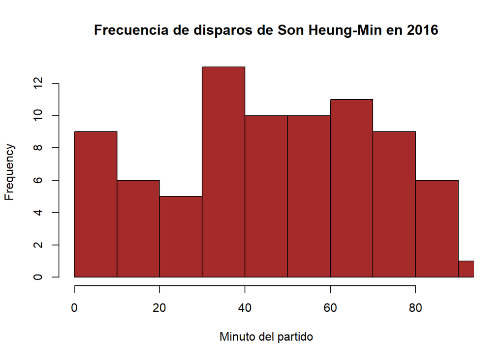

```r
hist(timegame2$minute, col = "brown", xlab = "Minuto del partido",xlim = c(0,90), main = "Frecuencia de disparos de Son Heung-Min en 2016")
```

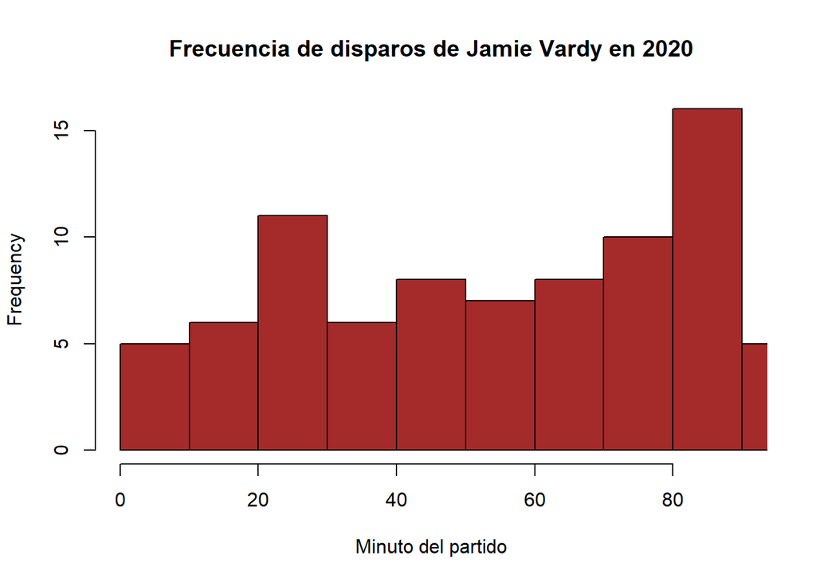

```r
disparos%>% filter(player == "Jamie Vardy" & season == 2020)-> timegame
disparos%>% filter(player == "Jamie Vardy" & season == 2018)-> timegame1
disparos%>% filter(player == "Jamie Vardy" & season == 2016)-> timegame2
hist(timegame$minute, col = "brown", xlab = "Minuto del partido",xlim = c(0,90), main = "Frecuencia de disparos de Jamie Vardy en 2020")
```

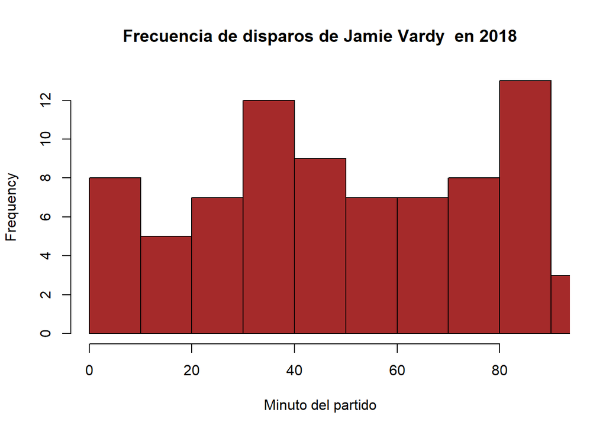

```r
hist(timegame1$minute, col = "brown", xlab = "Minuto del partido",xlim = c(0,90), main = "Frecuencia de disparos de Jamie Vardy  en 2018")
```

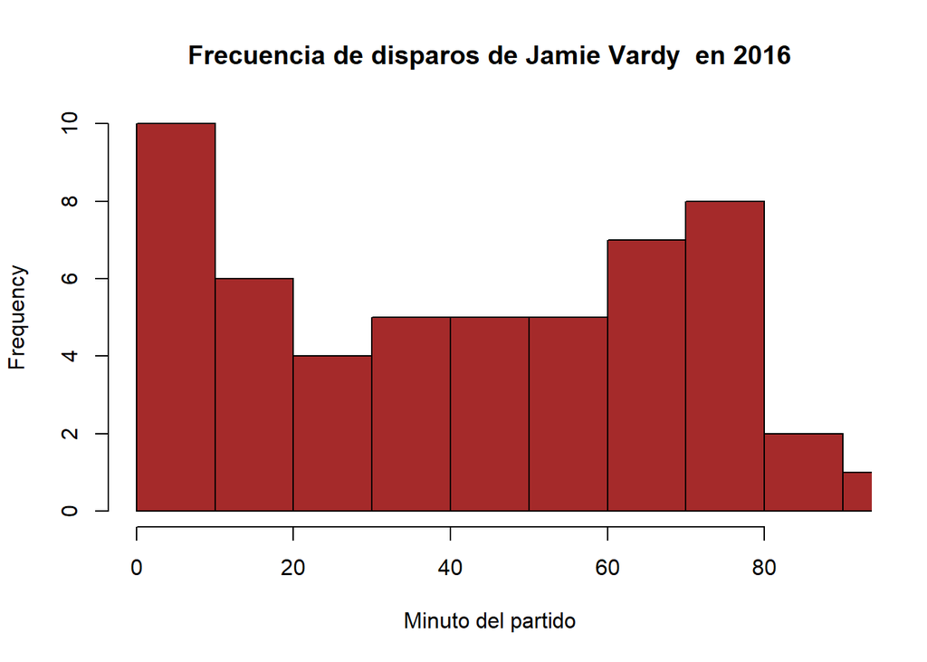

```r
hist(timegame2$minute, col = "brown", xlab = "Minuto del partido",xlim = c(0,90), main = "Frecuencia de disparos de Jamie Vardy  en 2016")
```

En la liga Italiana, el jugador que más destaco fue Andrea Belotti, Ciro Immobile, Dries Mertens y Edin Dzeko todas las temporadas – y su rendimiento en el campo se puede observar en el siguiente histograma.

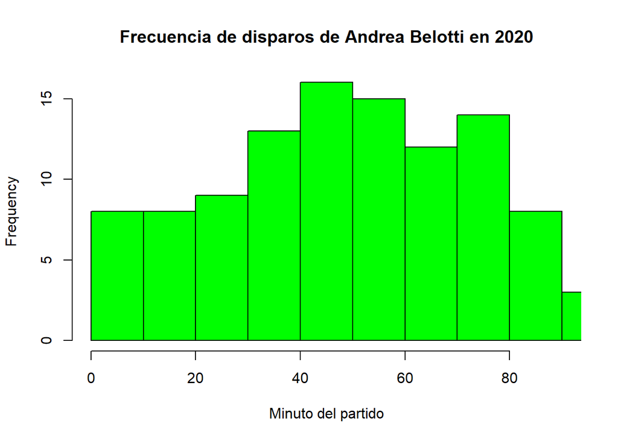

```r
disparos%>% filter(player == "Andrea Belotti" & season == 2020)-> timegame
disparos%>% filter(player == "Andrea Belotti" & season == 2018)-> timegame1
disparos%>% filter(player == "Andrea Belotti" & season == 2016)-> timegame2
hist(timegame$minute, col = "green", xlab = "Minuto del partido",xlim = c(0,90), main = "Frecuencia de disparos de Andrea Belotti en 2020")
```

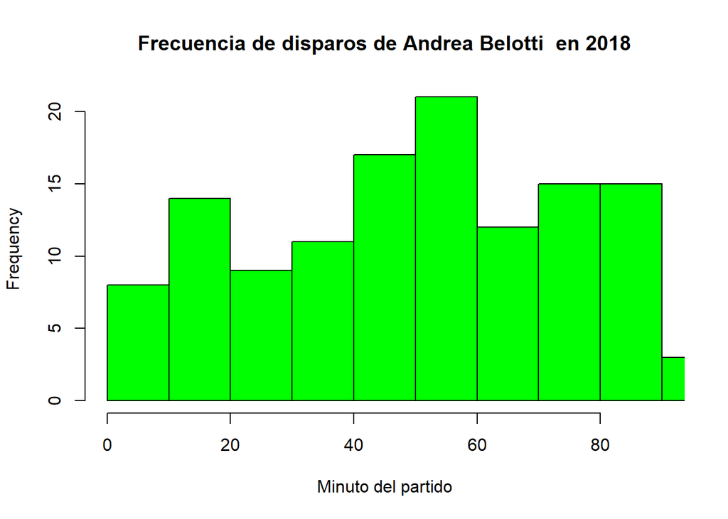

```r
hist(timegame1$minute, col = "green", xlab = "Minuto del partido",xlim = c(0,90), main = "Frecuencia de disparos de Andrea Belotti  en 2018")
```

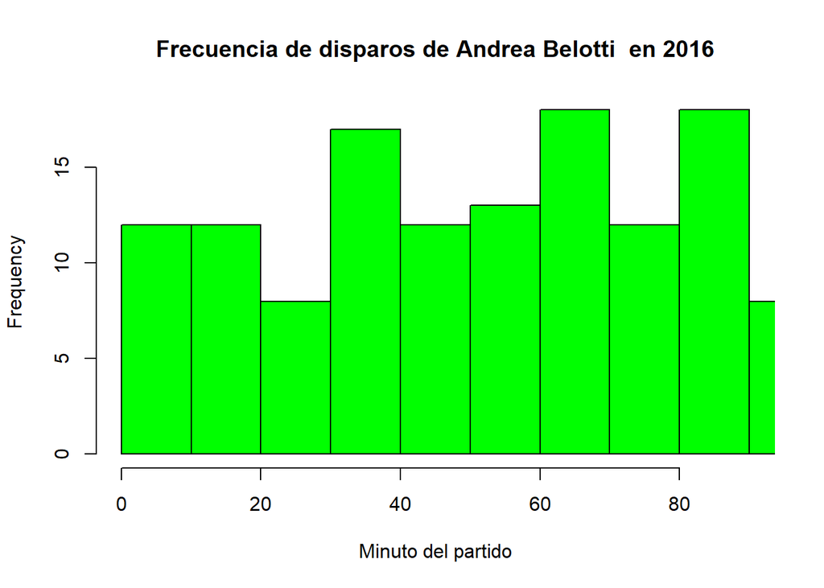

```r
hist(timegame2$minute, col = "green", xlab = "Minuto del partido",xlim = c(0,90), main = "Frecuencia de disparos de Andrea Belotti  en 2016")
```

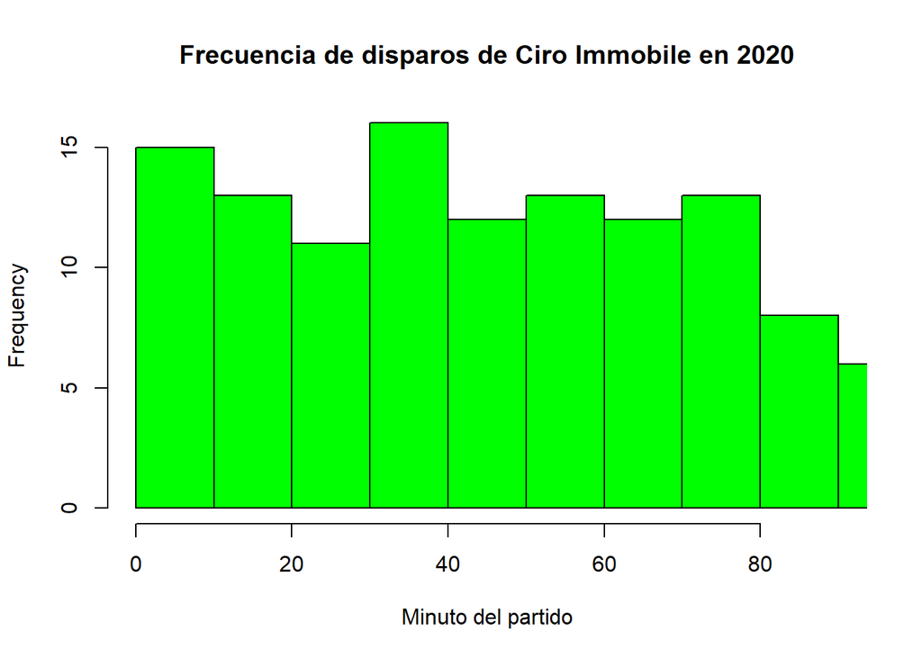

```r
disparos%>% filter(player == "Ciro Immobile" & season == 2020)-> timegame
disparos%>% filter(player == "Ciro Immobile" & season == 2018)-> timegame1
disparos%>% filter(player == "Ciro Immobile" & season == 2016)-> timegame2
hist(timegame$minute, col = "green", xlab = "Minuto del partido",xlim = c(0,90), main = "Frecuencia de disparos de Ciro Immobile en 2020")
```

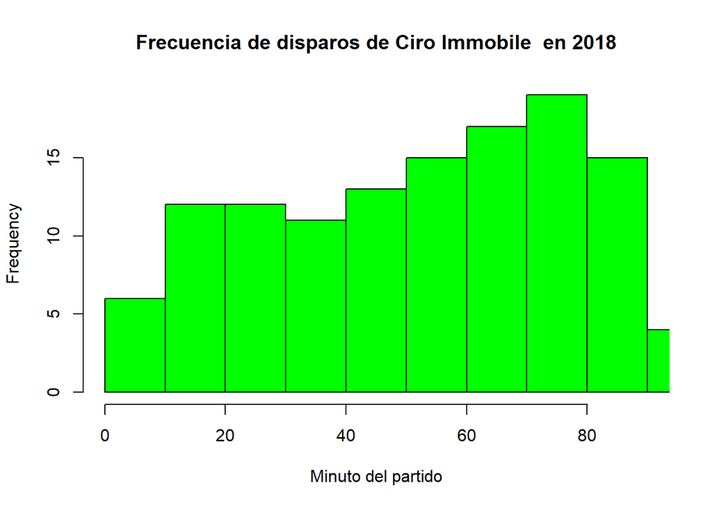

```r
hist(timegame1$minute, col = "green", xlab = "Minuto del partido",xlim = c(0,90), main = "Frecuencia de disparos de Ciro Immobile  en 2018")
```

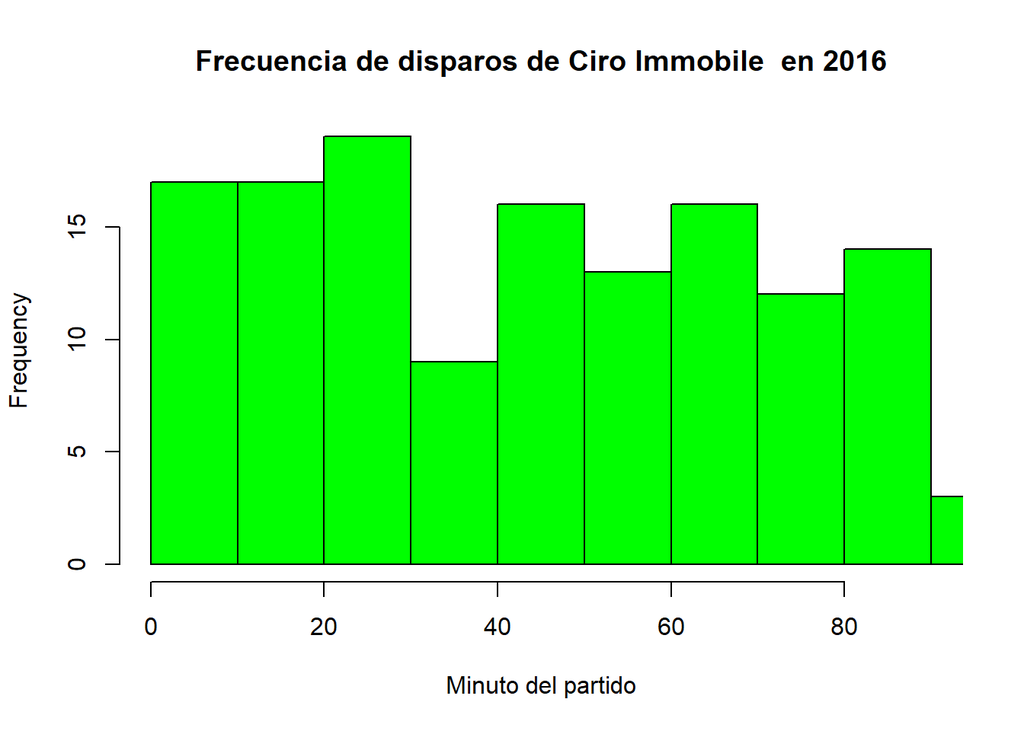

```r
hist(timegame2$minute, col = "green", xlab = "Minuto del partido",xlim = c(0,90), main = "Frecuencia de disparos de Ciro Immobile  en 2016")
```

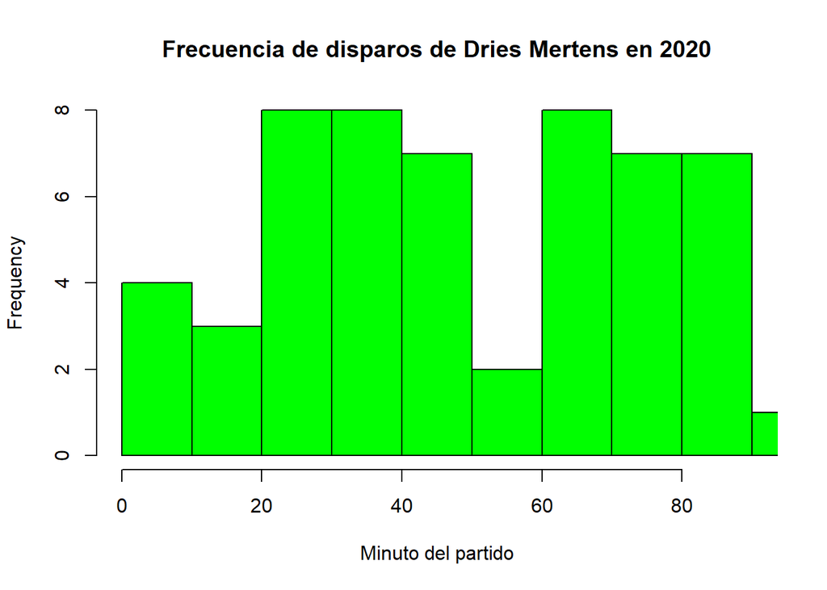

```r
disparos%>% filter(player == "Dries Mertens" & season == 2020)-> timegame
disparos%>% filter(player == "Dries Mertens" & season == 2018)-> timegame1
disparos%>% filter(player == "Dries Mertens" & season == 2016)-> timegame2
hist(timegame$minute, col = "green", xlab = "Minuto del partido",xlim = c(0,90), main = "Frecuencia de disparos de Dries Mertens en 2020")
```

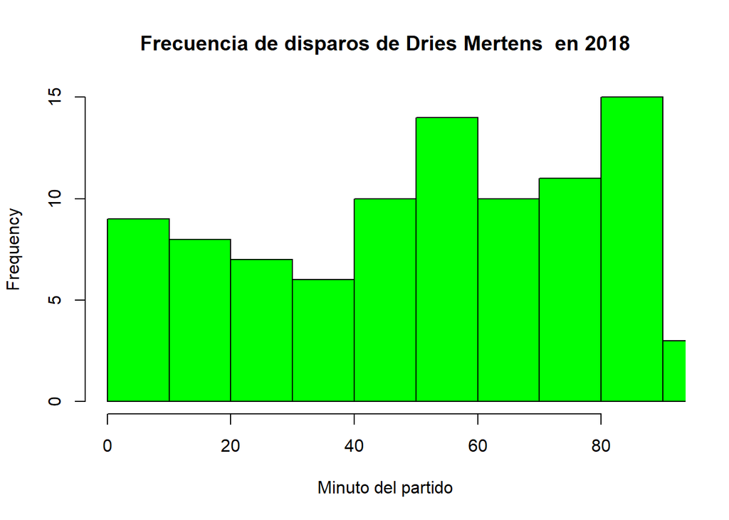

```r
hist(timegame1$minute, col = "green", xlab = "Minuto del partido",xlim = c(0,90), main = "Frecuencia de disparos de Dries Mertens  en 2018")
```

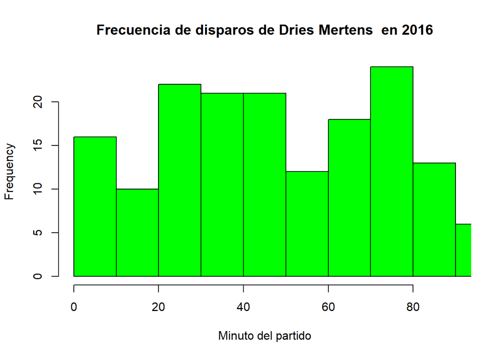

```r
hist(timegame2$minute, col = "green", xlab = "Minuto del partido",xlim = c(0,90), main = "Frecuencia de disparos de Dries Mertens  en 2016")
```

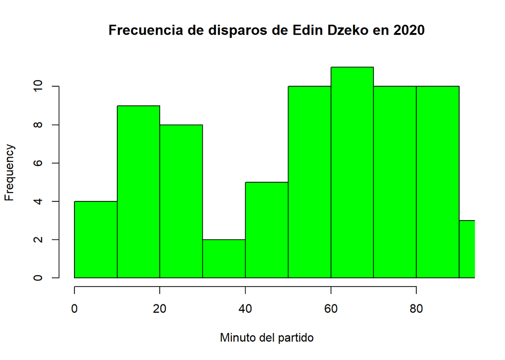

```r
disparos%>% filter(player == "Edin Dzeko" & season == 2020)-> timegame
disparos%>% filter(player == "Edin Dzeko" & season == 2018)-> timegame1
disparos%>% filter(player == "Edin Dzeko" & season == 2016)-> timegame2
hist(timegame$minute, col = "green", xlab = "Minuto del partido",xlim = c(0,90), main = "Frecuencia de disparos de Edin Dzeko en 2020")
```

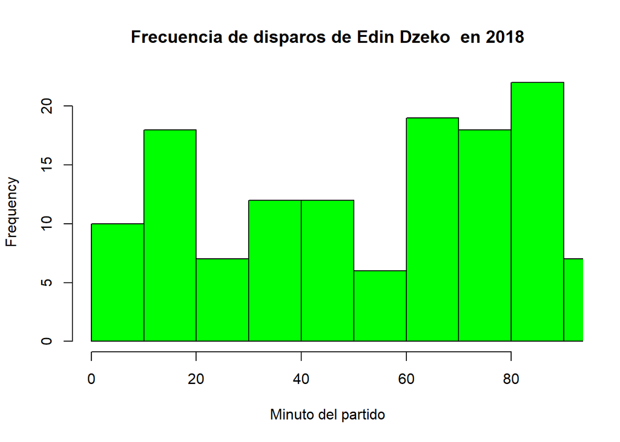

```r
hist(timegame1$minute, col = "green", xlab = "Minuto del partido",xlim = c(0,90), main = "Frecuencia de disparos de Edin Dzeko  en 2018")
```

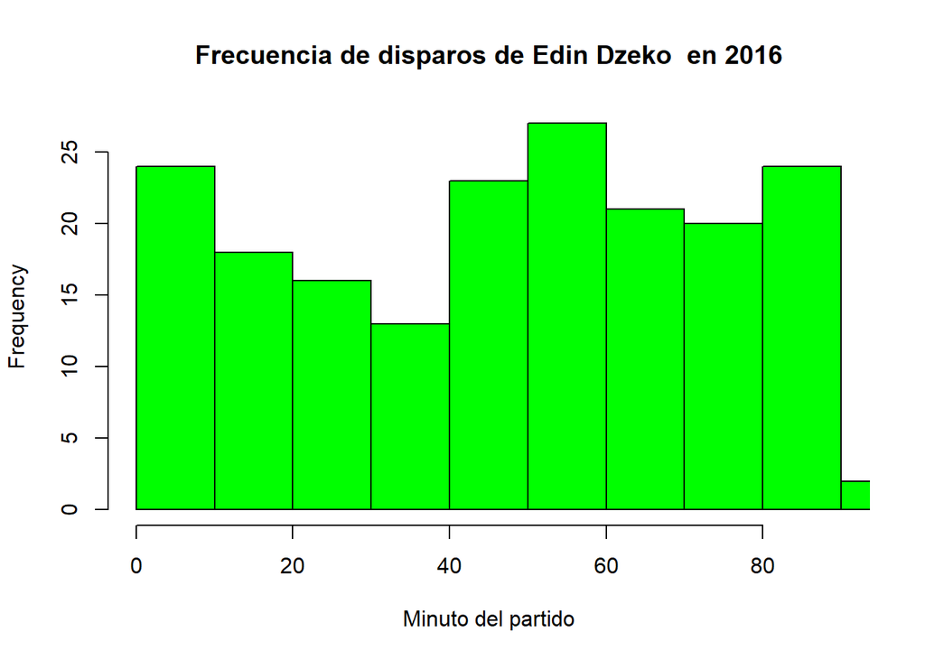

```r
hist(timegame2$minute, col = "green", xlab = "Minuto del partido",xlim = c(0,90), main = "Frecuencia de disparos de Edin Dzeko  en 2016")
```

Nos encontramos con unos valores altos en comparacion de otras ligas, lo que reflejaria un mejor juego individual en la liga italiana frente a las otras ligas.

+Analisis de los partidos- + Histograma de los minutos en los que se realizan disparos en un partido

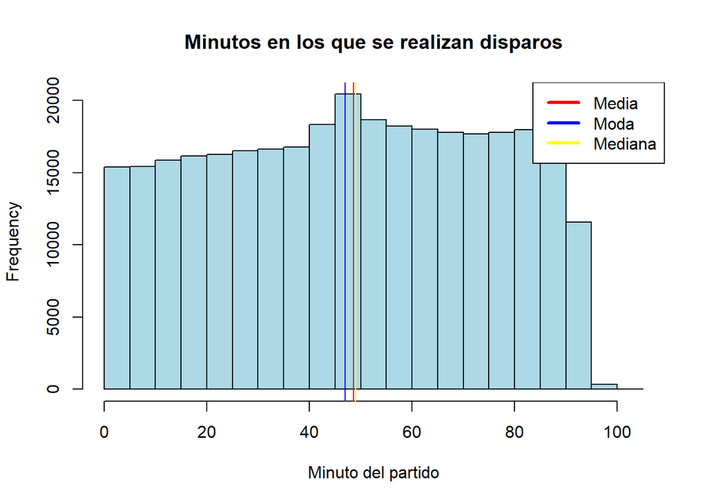

```r
hist(disparos$minute, main = "Minutos en los que se realizan disparos", col = "lightblue",xlab = "Minuto del partido")
abline(v=mean(disparos$minute), col = "red")
abline(v=which.max(table(disparos$minute)), col = "blue")
abline(v=median(disparos$minute), col = "yellow")
legend("topright", c("Media","Moda","Mediana"), col = c("red","blue","yellow"), lwd=3, lty=1)
```

LIGA ALEMANA

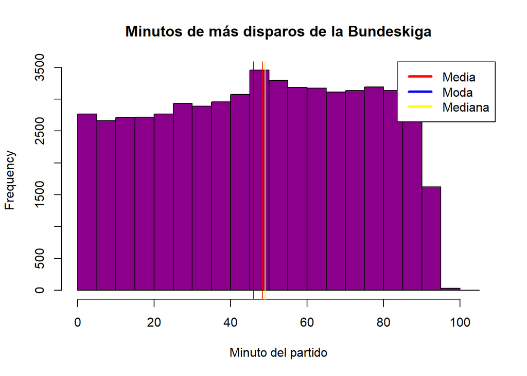

```r
disparos%>% filter(league == "Bundesliga")-> disp_bundesliga
hist(disp_bundesliga$minute,main = "Minutos de más disparos de la Bundeskiga", col = "darkmagenta",xlab = "Minuto del partido")
abline(v=mean(disp_bundesliga$minute), col = "red")
abline(v=which.max(table(disp_bundesliga$minute)), col = "blue")
abline(v=median(disp_bundesliga$minute), col = "yellow")
legend("topright", c("Media","Moda","Mediana"), col = c("red","blue","yellow"), lwd=3, lty=1)
```

LIGA FRANCESA

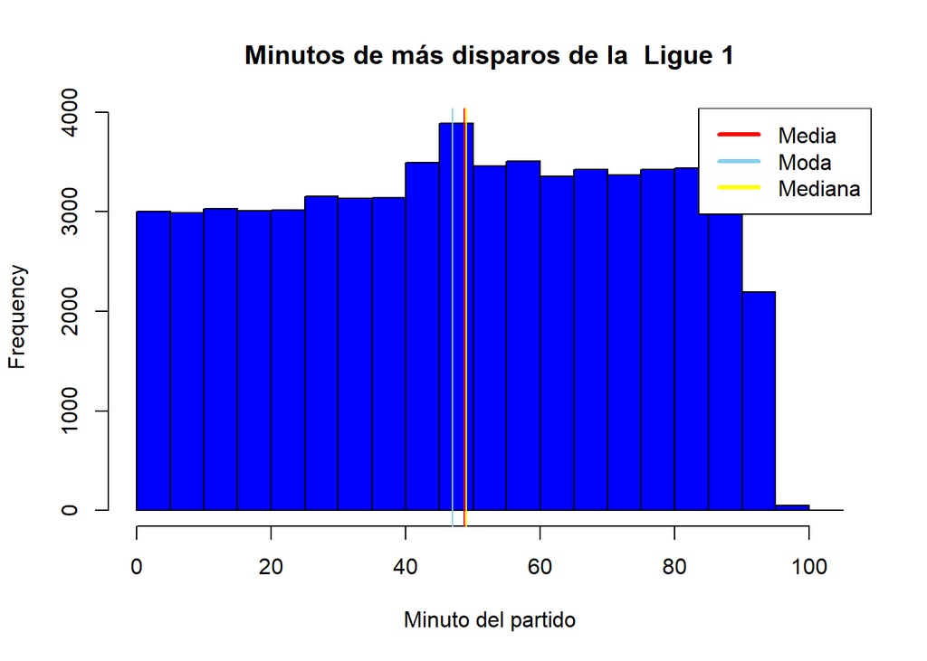

```r
disparos%>% filter(league == "Ligue 1")-> disp_Ligue1
hist(disp_Ligue1$minute,main = "Minutos de más disparos de la  Ligue 1", col = "blue",xlab = "Minuto del partido")
abline(v=mean(disp_Ligue1$minute), col = "red")
abline(v=which.max(table(disp_Ligue1$minute)), col = "skyblue")
abline(v=median(disp_Ligue1$minute), col = "yellow")
legend("topright", c("Media","Moda","Mediana"), col = c("red","skyblue","yellow"), lwd=3, lty=1)
```

LIGA ESPANOLA

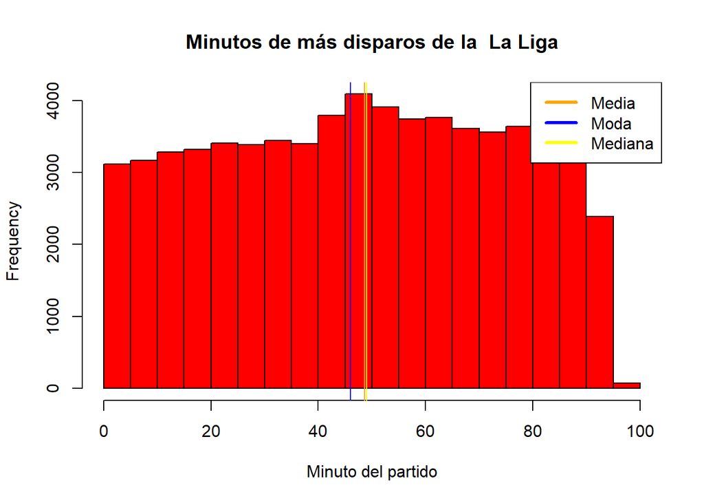

```r
disparos%>% filter(league == "La Liga")-> disp_LaLiga
hist(disp_LaLiga$minute,main = "Minutos de más disparos de la  La Liga", col = "red",xlab = "Minuto del partido")
abline(v=mean(disp_LaLiga$minute), col = "orange")
abline(v=which.max(table(disp_LaLiga$minute)), col = "blue")
abline(v=median(disp_LaLiga$minute), col = "yellow")
legend("topright", c("Media","Moda","Mediana"), col = c("orange","blue","yellow"), lwd=3, lty=1)
```

LIGA INGLESA

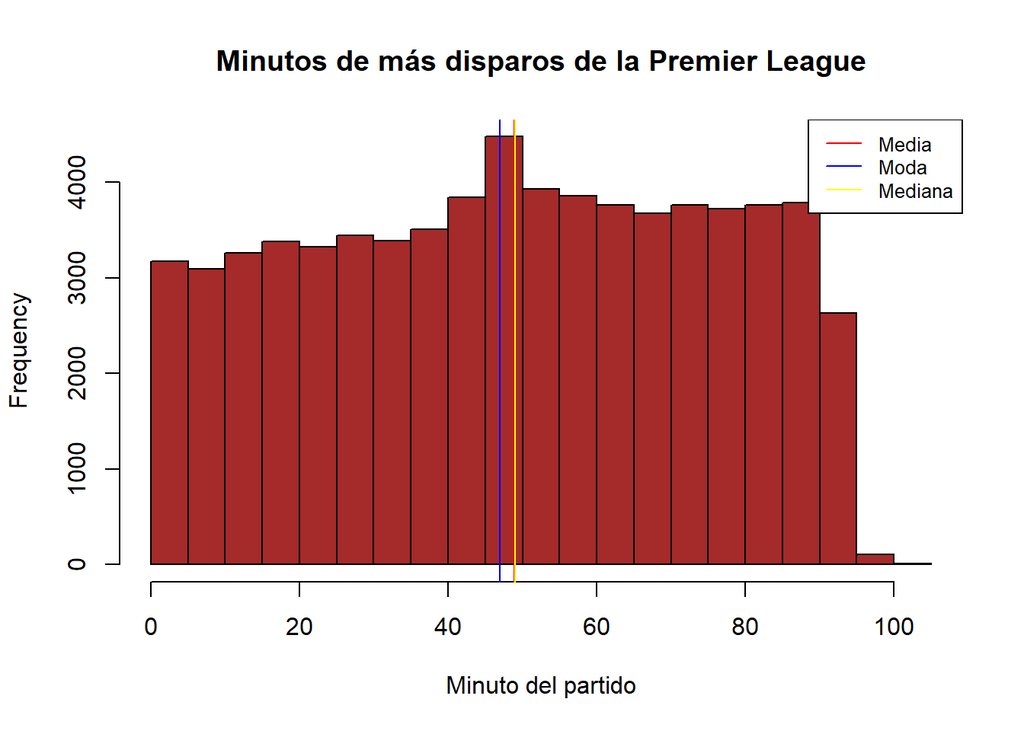

```r
disparos%>% filter(league == "Premier League")-> disp_premierleague
hist(disp_premierleague$minute,main = "Minutos de más disparos de la Premier League", col = "brown",xlab = "Minuto del partido")
abline(v=mean(disp_premierleague$minute), col = "red")
abline(v=which.max(table(disp_premierleague$minute)), col = "blue")
abline(v=median(disp_premierleague$minute), col = "yellow")
legend("topright", c("Media","Moda","Mediana"), col = c("red","blue","yellow"), cex=0.8, pt.cex =0.8, lwd=1, lty=1 )
```

LIGA ITALIANA

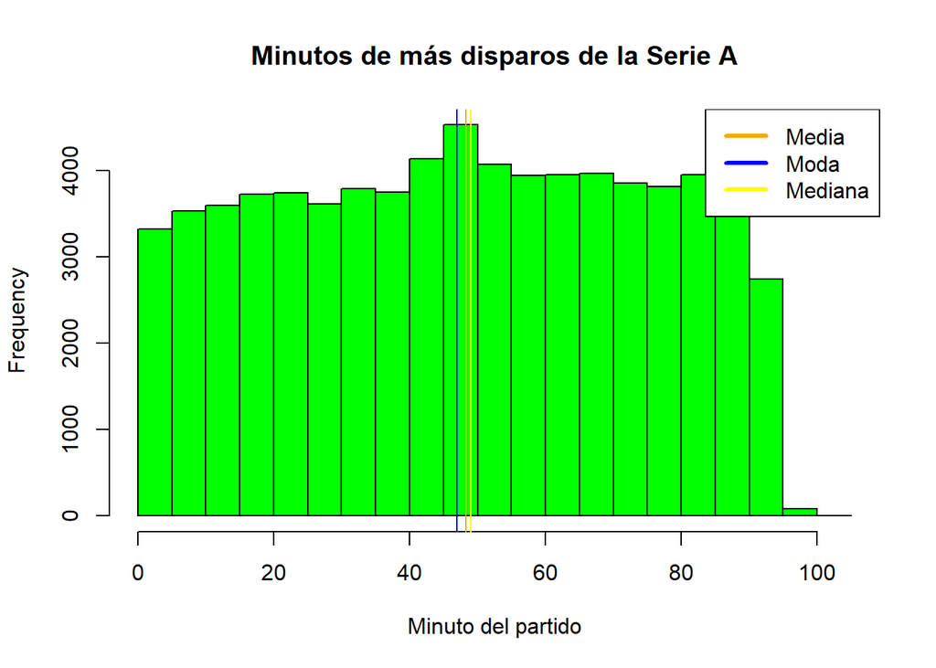

```r
disparos%>% filter(league == "Serie A")-> disp_SerieA
hist(disp_SerieA$minute,main = "Minutos de más disparos de la Serie A", col = "green",xlab = "Minuto del partido")
abline(v=mean(disp_SerieA$minute), col = "orange")
abline(v=which.max(table(disp_SerieA$minute)), col = "blue")
abline(v=median(disp_SerieA$minute), col = "yellow")
legend("topright", c("Media","Moda","Mediana"), col = c("orange","blue","yellow"), lwd=3, lty=1)
```

Este histograma de los minutos en los que se realizan disparos nos muestra una distribución simétrica de la variable en cuestión, lo cual se puede apreciar tanto visualmente como a través de la media, la moda y la mediana, las cuales se encuentran en valores aproximados entre sí.

- Boxplot de las tarjetas amarillas recibidas por cada equipo del 2015 al 2020

# Ivan Gonzales y Rodrigo

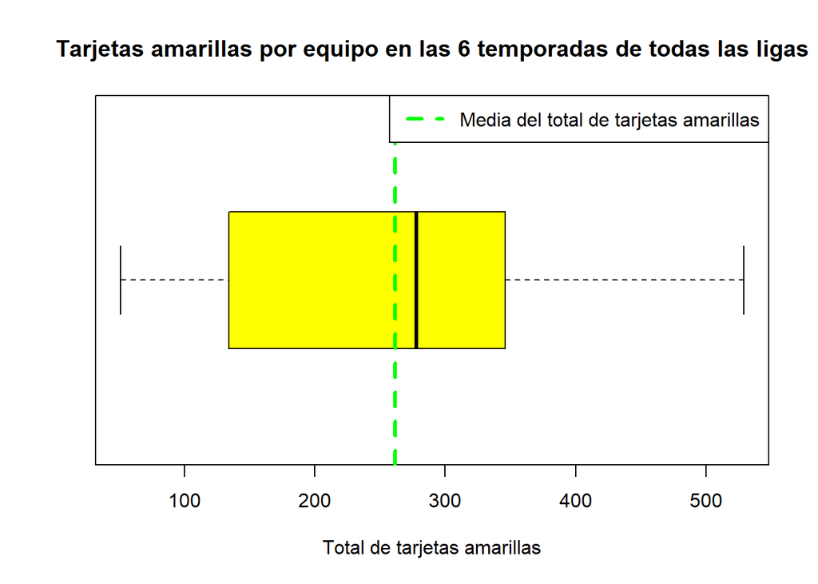

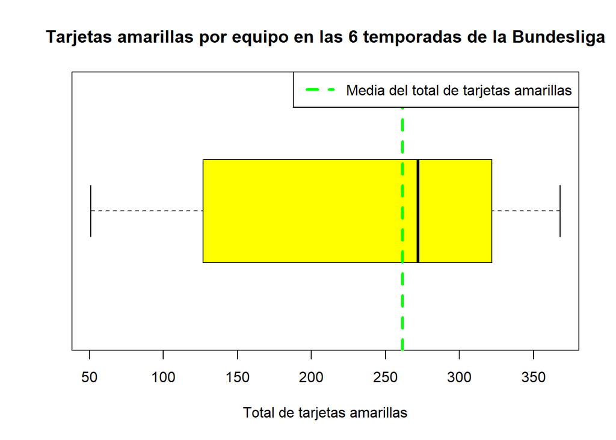

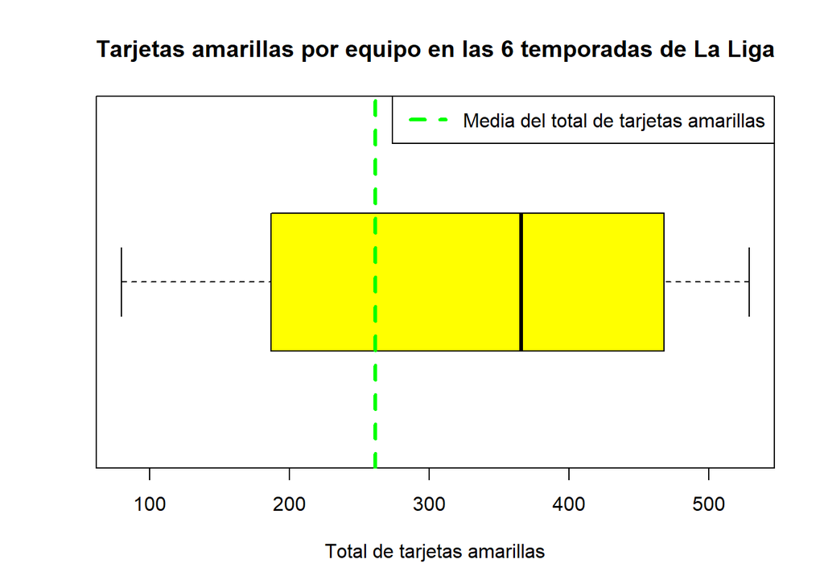

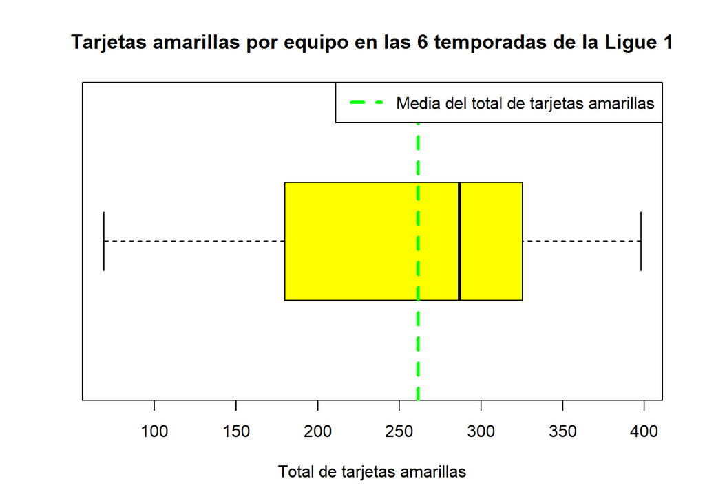

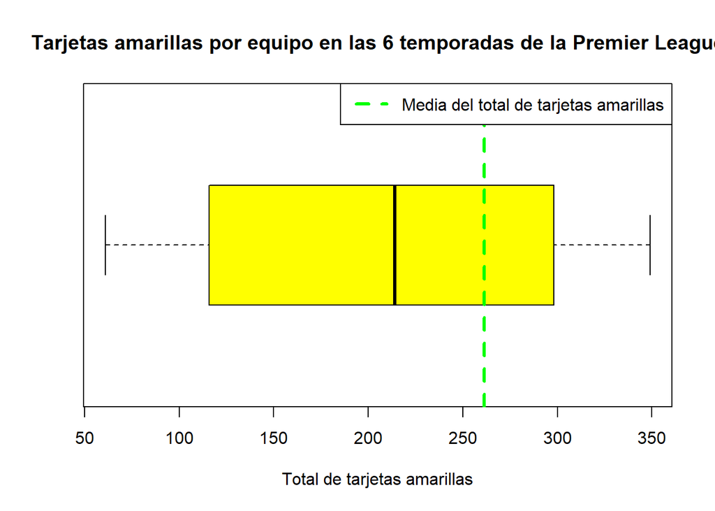

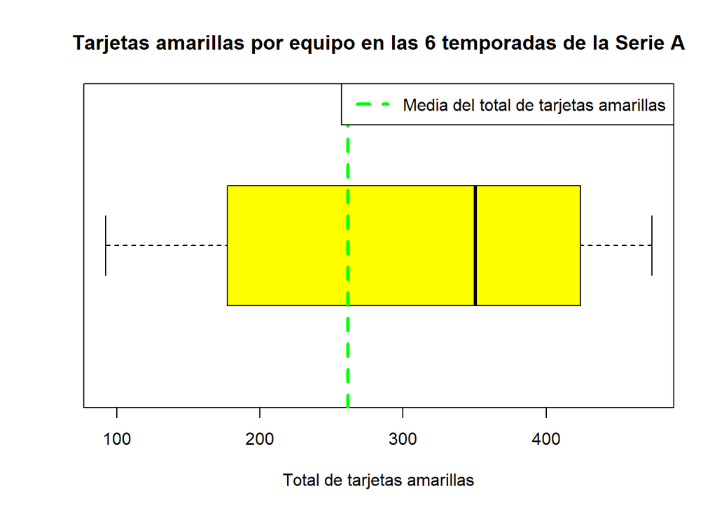

ANALISIS

- Boxplot de los promedio de goles de cada jugador de la temporada 2016 al 2020

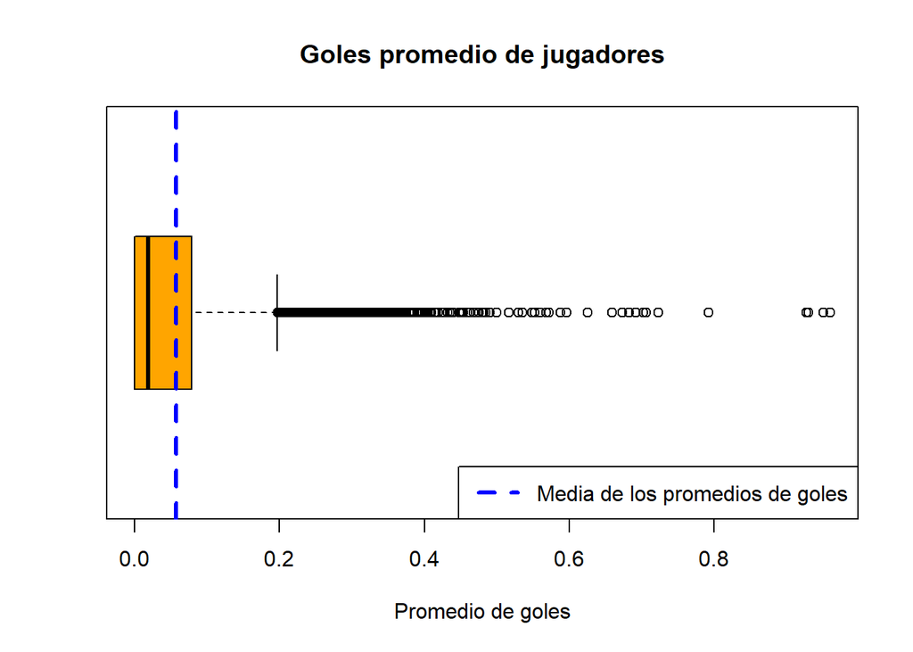

```r
boxplot(n_goals$goal_avg, col = "orange",horizontal = TRUE, main = "Goles promedio de jugadores", xlab= "Promedio de goles")
abline(v=mean(n_goals$goal_avg), col = "blue",lwd=3, lty=2)
legend("bottomright", c("Media de los promedios de goles"), col = "blue", lwd=3 , lty=2 )
```

La mayoria de jugadores en un partido anotan 1 o ni un gol, mientras que hay casos muy particulares en la que pocos jugadores tienen un promedio cercano a un gol por partido, cuyos promedios correspsonden a los jugadores mas reconocidos del mundo como lo son Messi o Cristiano Ronaldo. Los puntos que representan datos atípicos, son en su mayoria delanteros, jugadores que estan en constante interacción con el arco del equipo contrario.

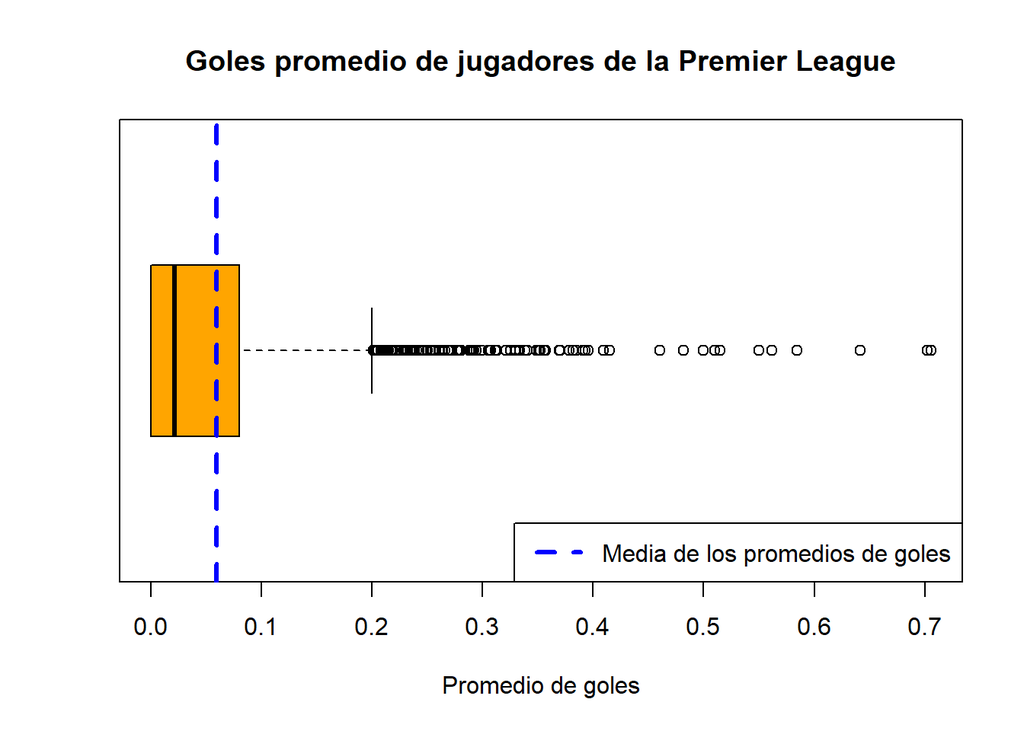

```r
#Identificar y ordenar por color de pertenecientes a cada liga
boxplot(n_goalPremierLeague$goal_avg, col = "orange",horizontal = TRUE, main = "Goles promedio de jugadores de la Premier League", xlab= "Promedio de goles")
abline(v=mean(n_goalPremierLeague$goal_avg), col = "blue",lwd=3, lty=2)
legend("bottomright", c("Media de los promedios de goles"), col = "blue", lwd=3 , lty=2 )
```

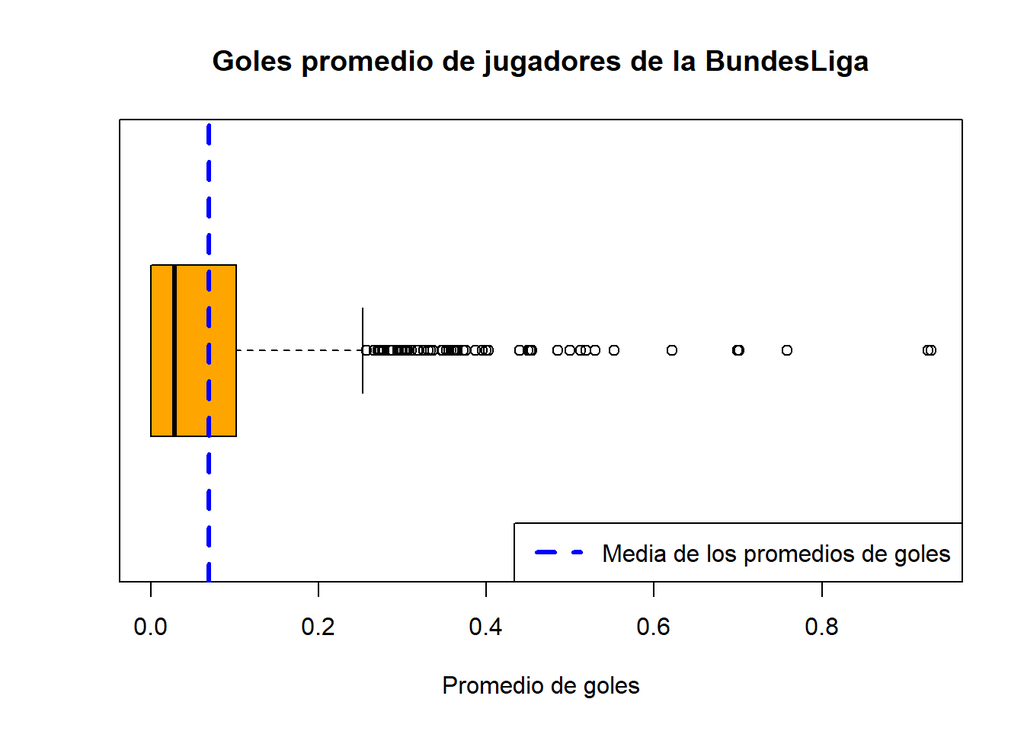

```r
boxplot(n_goalBundesliga$goal_avg, col = "orange",horizontal = TRUE, main = "Goles promedio de jugadores de la BundesLiga", xlab= "Promedio de goles")
abline(v=mean(n_goalBundesliga$goal_avg), col = "blue",lwd=3, lty=2)
legend("bottomright", c("Media de los promedios de goles"), col = "blue", lwd=3 , lty=2 )
```

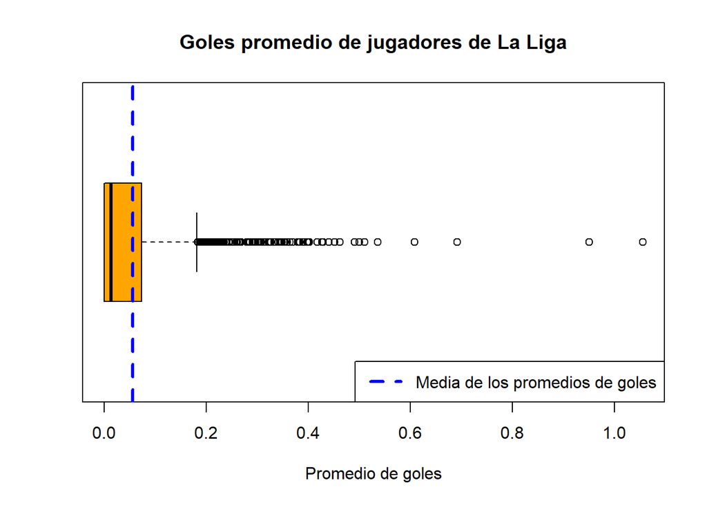

```r
boxplot(n_goalLaLiga$goal_avg, col = "orange",horizontal = TRUE, main = "Goles promedio de jugadores de La Liga", xlab= "Promedio de goles")
abline(v=mean(n_goalLaLiga$goal_avg), col = "blue",lwd=3, lty=2)
legend("bottomright", c("Media de los promedios de goles"), col = "blue", lwd=3 , lty=2 )
```

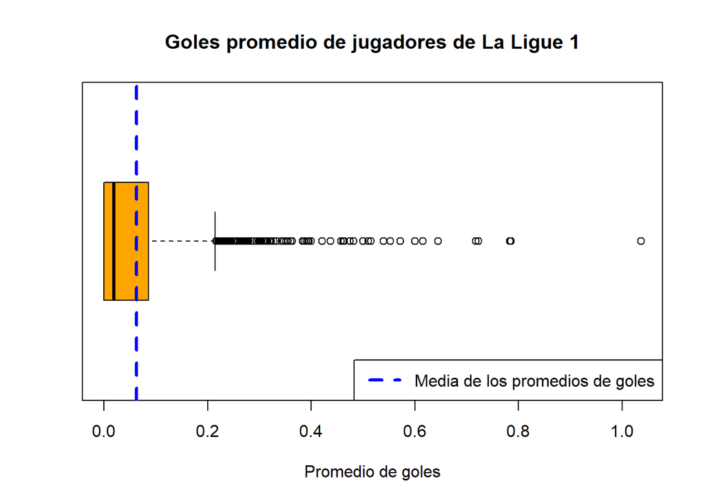

```r
boxplot(n_goalLigue1$goal_avg, col = "orange",horizontal = TRUE, main = "Goles promedio de jugadores de La Ligue 1", xlab= "Promedio de goles")
abline(v=mean(n_goalLigue1$goal_avg), col = "blue",lwd=3, lty=2)
legend("bottomright", c("Media de los promedios de goles"), col = "blue", lwd=3 , lty=2 )
```

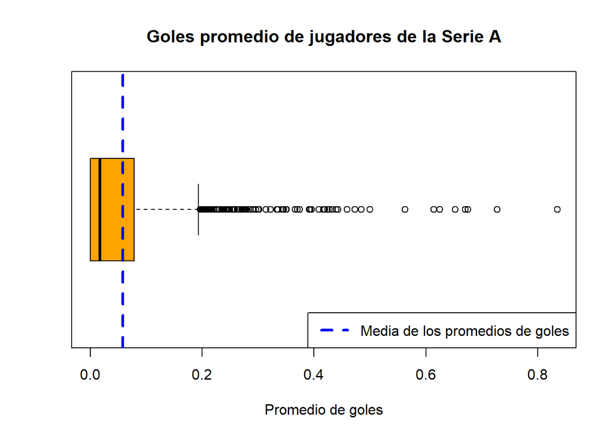

```r
boxplot(n_goalSerieA$goal_avg, col = "orange",horizontal = TRUE, main = "Goles promedio de jugadores de la Serie A", xlab= "Promedio de goles")
abline(v=mean(n_goalSerieA$goal_avg), col = "blue",lwd=3, lty=2)
legend("bottomright", c("Media de los promedios de goles"), col = "blue", lwd=3 , lty=2 )
```

```r
estadistica_equipos %>% group_by(season,league) %>% summarise(goles_totales = sum(goals)) %>% filter(league == "Bundesliga") -> alemania
estadistica_equipos %>% group_by(season,league) %>% summarise(goles_totales = sum(goals)) %>% filter(league == "Premier League") -> inglesa
estadistica_equipos %>% group_by(season,league) %>% summarise(goles_totales = sum(goals)) %>% filter(league == "Ligue 1") -> francesa
estadistica_equipos %>% group_by(season,league) %>% summarise(goles_totales = sum(goals)) %>% filter(league == "La Liga") -> española
estadistica_equipos %>% group_by(season,league) %>% summarise(goles_totales = sum(goals)) %>% filter(league == "Serie A") -> italiana
```

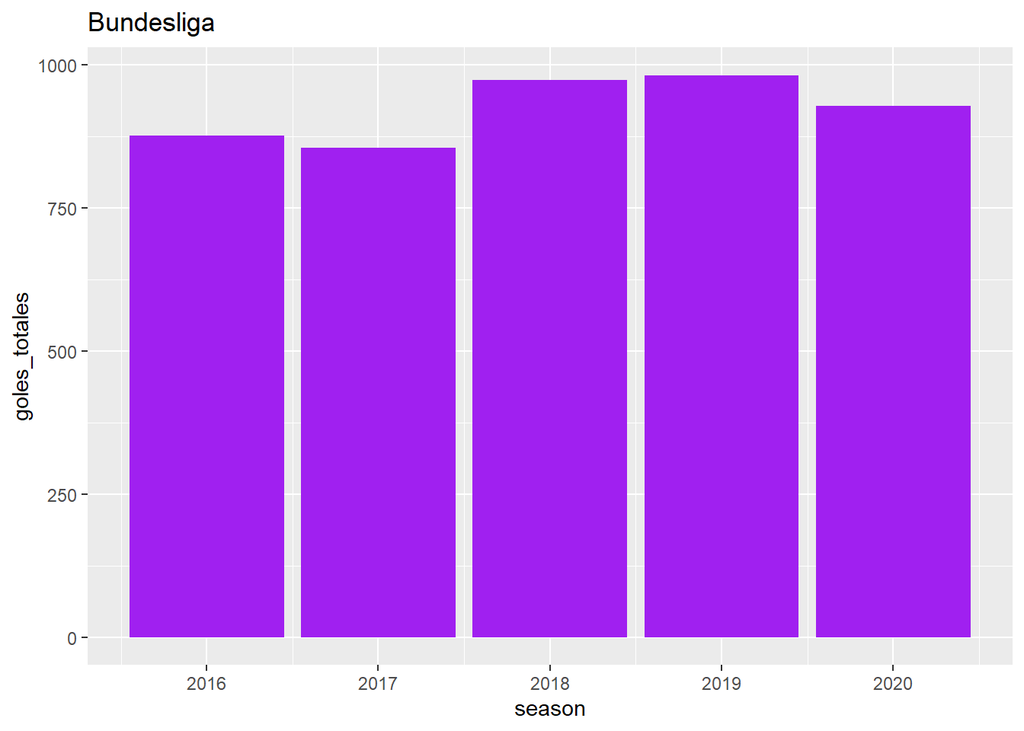

```r
ggplot(alemania,aes(x=season,y=goles_totales)) + geom_bar(stat = "identity",fill = "purple") + ggtitle("Bundesliga ")
```

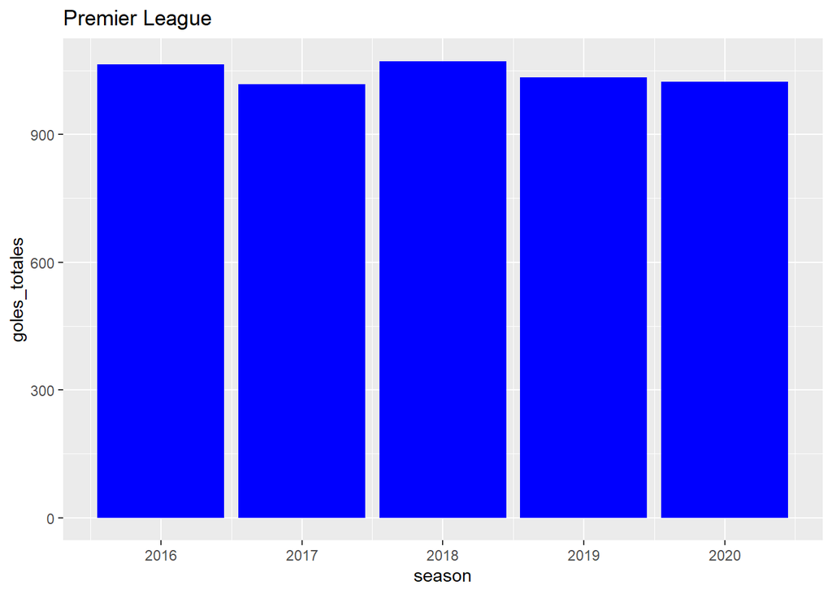

```r
ggplot(inglesa,aes(x=season,y=goles_totales)) + geom_bar(stat = "identity",fill = "blue") + ggtitle("Premier League")
```

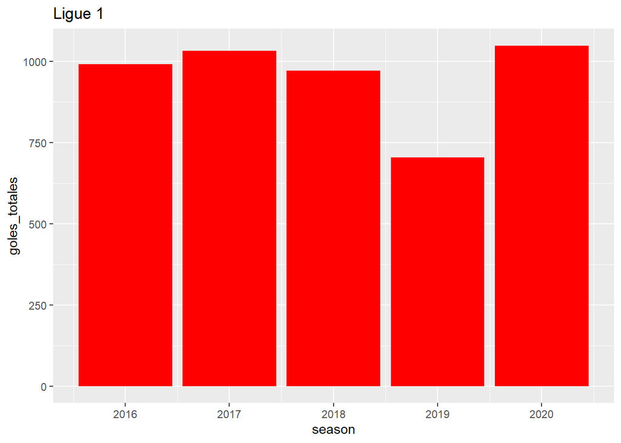

```r
ggplot(francesa,aes(x=season,y=goles_totales)) + geom_bar(stat = "identity",fill = "red") + ggtitle("Ligue 1 ")
```

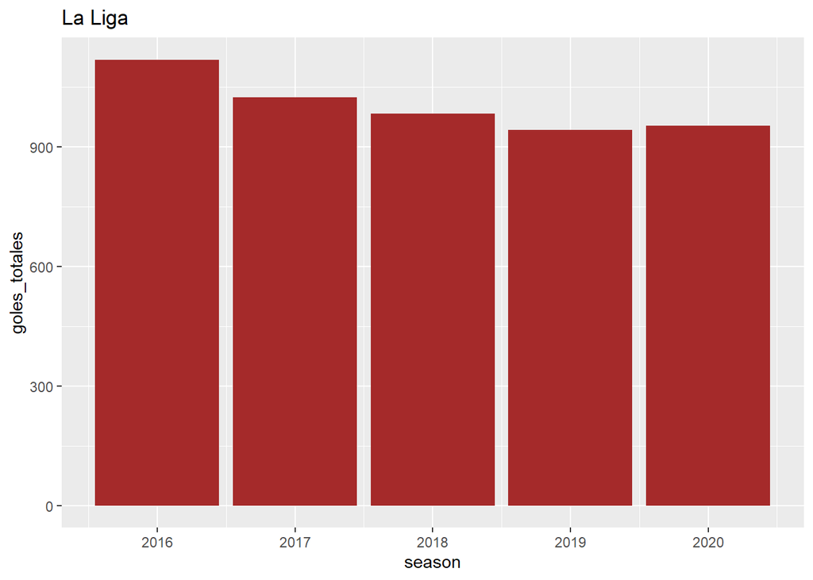

```r
ggplot(española,aes(x=season,y=goles_totales)) + geom_bar(stat = "identity",fill = "brown") + ggtitle("La Liga ")
```

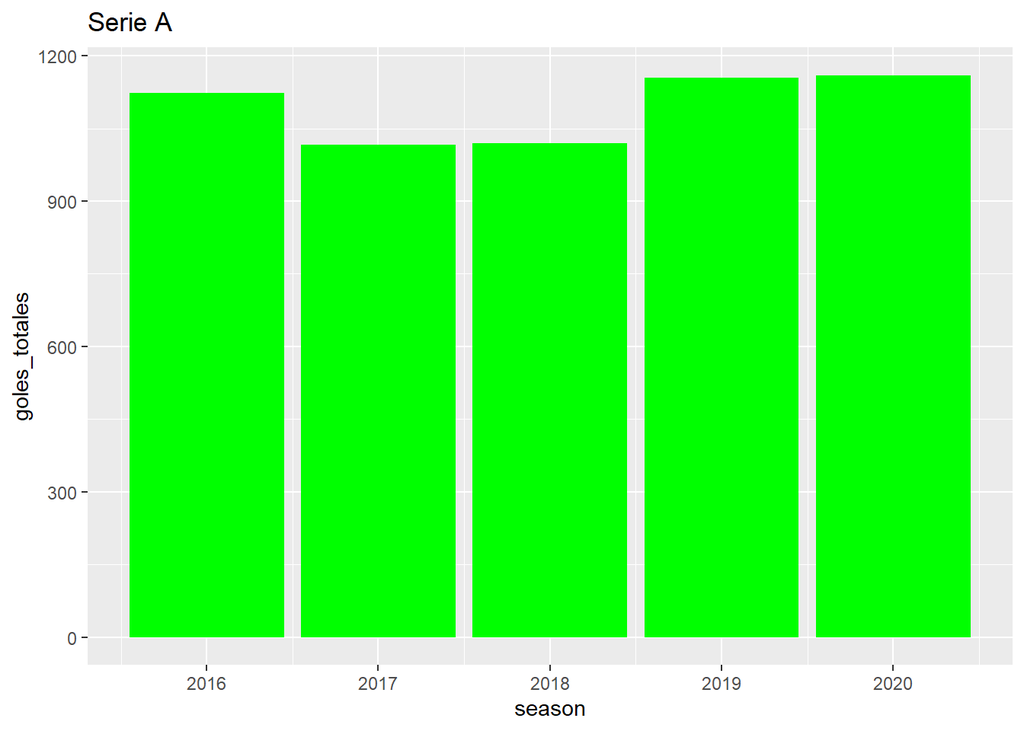

```r
ggplot(italiana,aes(x=season,y=goles_totales)) + geom_bar(stat = "identity",fill = "green") + ggtitle("Serie A")
```

Como se puede apreciar en la gráfica vemos que la mayoría de ligas mantienen un numero igual de goles por temporada exceptuando algunos casos especiales que son la temporada 2019 de La Ligue y las temporadas 2016 y 2017 de la Bundesliga.

# 7.Relaciones entre variable

Se va evaluar al equipo y a la principales estrellas de cada equipo en las temporadas en mencion debido a su comportamiento.

Liga Alemana Liga Espanola Liga Francesa Liga Inglesa Liga Italiana

```r
cor(LigaAlemana_equipo$gol_tem, LigaAlemana_equipo$gtshot_sum)
```

```
## [1] 0.970891
```

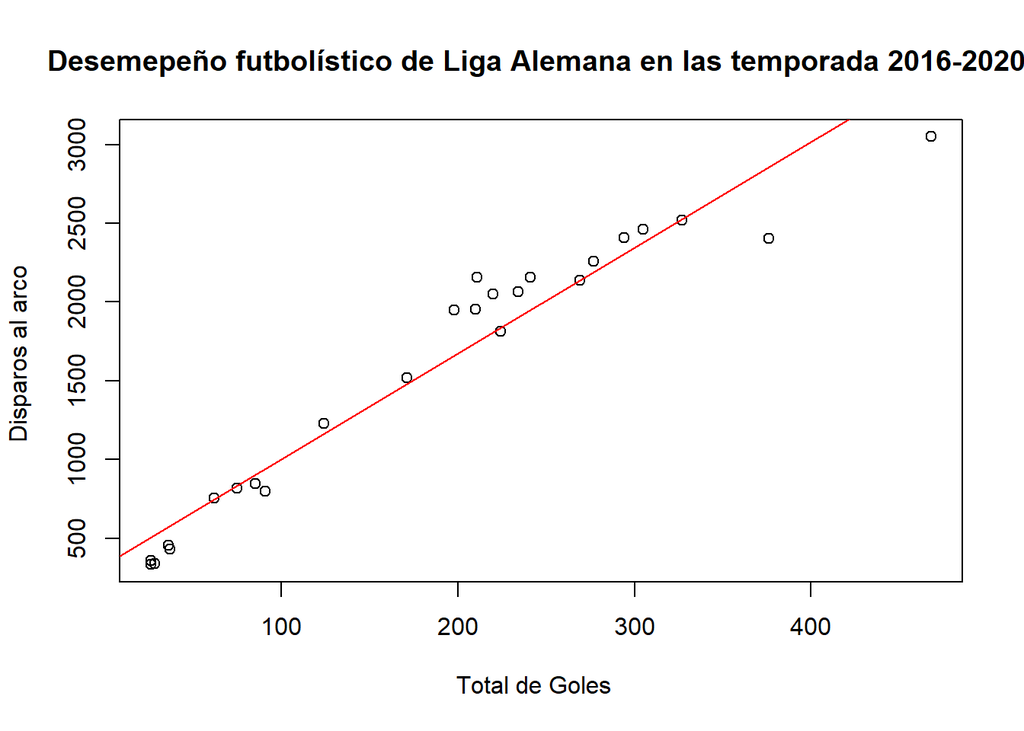

```r
regresion_lineal3<-lm(LigaAlemana_equipo$gtshot_sum~ LigaAlemana_equipo$gol_tem)
plot(LigaAlemana_equipo$gol_tem, LigaAlemana_equipo$gtshot_sum,  main="Desemepeño futbolístico de Liga Alemana en las temporada 2016-2020.",
        xlab="Total de Goles  ",
        ylab="Disparos al arco ",)
abline(regresion_lineal3, col='red')
```

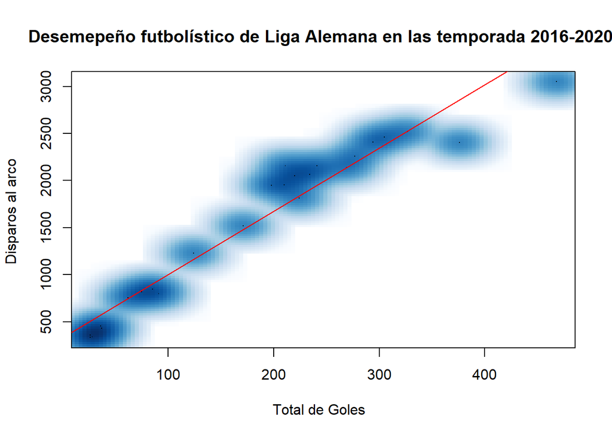

```r
smoothScatter(LigaAlemana_equipo$gol_tem, LigaAlemana_equipo$gtshot_sum,  main="Desemepeño futbolístico de Liga Alemana en las temporada 2016-2020.",
        xlab="Total de Goles  ",
        ylab="Disparos al arco ",)

abline(regresion_lineal3, col='red')
```

```r
summary(regresion_lineal3)
```

```
##
## Call:
## lm(formula = LigaAlemana_equipo$gtshot_sum ~ LigaAlemana_equipo$gol_tem)
##
## Residuals:
##     Min      1Q  Median      3Q     Max
## -452.44 -143.33    0.19  103.29  408.73
##
## Coefficients:
##                            Estimate Std. Error t value Pr(>|t|)
## (Intercept)                331.1529    75.9921   4.358 0.000231 ***
## LigaAlemana_equipo$gol_tem   6.7162     0.3455  19.440 8.98e-16 ***
## ---
## Signif. codes:  0 '***' 0.001 '**' 0.01 '*' 0.05 '.' 0.1 ' ' 1
##
## Residual standard error: 206.6 on 23 degrees of freedom
## Multiple R-squared:  0.9426, Adjusted R-squared:  0.9401
## F-statistic: 377.9 on 1 and 23 DF,  p-value: 8.976e-16
```

```r
coefficients(regresion_lineal3)
```

```
##                (Intercept) LigaAlemana_equipo$gol_tem
##                 331.152902                   6.716181
```

Entonces tenemos la siguiente formula:
$$\begin{equation}
f(x)=331.15902 + 6.716181x
\end{equation}$$

```r
cor(LigaEspanola_equipo$gol_tem, LigaEspanola_equipo$gtshot_sum)
```

```
## [1] 0.9561872
```

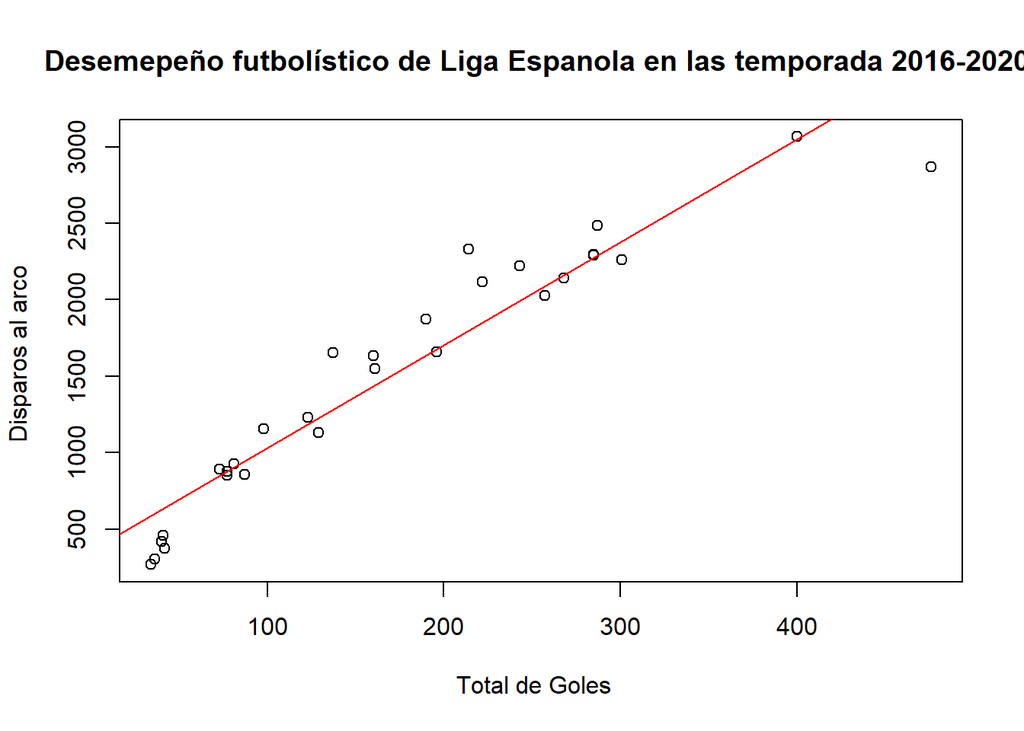

```r
regresion_lineal3<-lm(LigaEspanola_equipo$gtshot_sum~ LigaEspanola_equipo$gol_tem)
plot(LigaEspanola_equipo$gol_tem, LigaEspanola_equipo$gtshot_sum,  main="Desemepeño futbolístico de Liga Espanola en las temporada 2016-2020.",
        xlab="Total de Goles  ",
        ylab="Disparos al arco ",)

abline(regresion_lineal3, col='red')
```

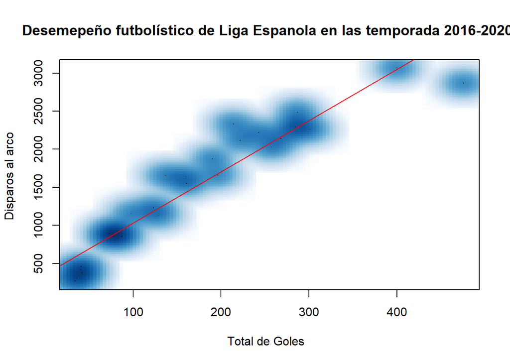

```r
smoothScatter(LigaEspanola_equipo$gol_tem, LigaEspanola_equipo$gtshot_sum,  main="Desemepeño futbolístico de Liga Espanola en las temporada 2016-2020.",
        xlab="Total de Goles  ",
        ylab="Disparos al arco ",)

abline(regresion_lineal3, col='red')
```

```r
summary(regresion_lineal3)
```

```
##
## Call:
## lm(formula = LigaEspanola_equipo$gtshot_sum ~ LigaEspanola_equipo$gol_tem)
##
## Residuals:
##     Min      1Q  Median      3Q     Max
## -695.71  -94.86   14.46  133.73  532.20
##
## Coefficients:
##                             Estimate Std. Error t value Pr(>|t|)
## (Intercept)                 359.8634    81.9495   4.391 0.000156 ***
## LigaEspanola_equipo$gol_tem   6.7287     0.3965  16.971 6.25e-16 ***
## ---
## Signif. codes:  0 '***' 0.001 '**' 0.01 '*' 0.05 '.' 0.1 ' ' 1
##
## Residual standard error: 241.2 on 27 degrees of freedom
## Multiple R-squared:  0.9143, Adjusted R-squared:  0.9111
## F-statistic:   288 on 1 and 27 DF,  p-value: 6.251e-16
```

```r
coefficients(regresion_lineal3)
```

```
##                 (Intercept) LigaEspanola_equipo$gol_tem
##                  359.863375                    6.728678
```

Entonces tenemos la siguiente formula:
$$\begin{equation}
f(x)= 359.863375 + 6.728678x
\end{equation}$$

```r
cor(LigaFrancia_equipo$gol_tem, LigaFrancia_equipo$gtshot_sum)
```

```
## [1] 0.9301711
```

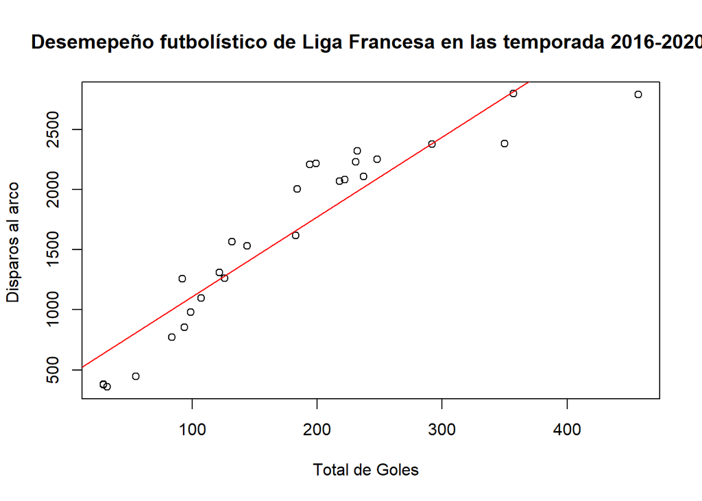

```r
regresion_lineal3<-lm(LigaFrancia_equipo$gtshot_sum~ LigaFrancia_equipo$gol_tem)
plot(LigaFrancia_equipo$gol_tem, LigaFrancia_equipo$gtshot_sum,  main="Desemepeño futbolístico de Liga Francesa en las temporada 2016-2020.",
        xlab="Total de Goles  ",
        ylab="Disparos al arco ",)

abline(regresion_lineal3, col='red')
```

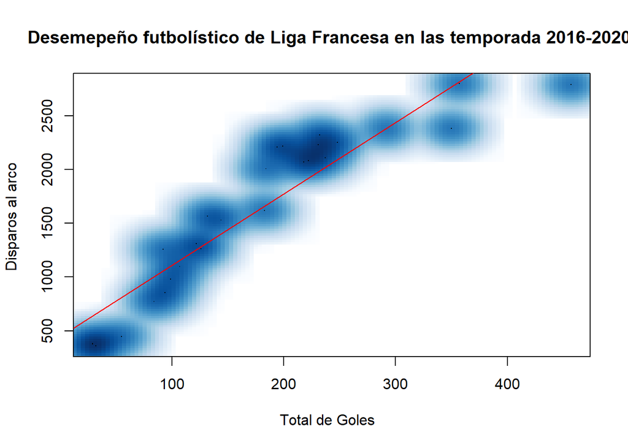

```r
smoothScatter(LigaFrancia_equipo$gol_tem, LigaFrancia_equipo$gtshot_sum,  main="Desemepeño futbolístico de Liga Francesa en las temporada 2016-2020.",
        xlab="Total de Goles  ",
        ylab="Disparos al arco ",)

abline(regresion_lineal3, col='red')
```

```r
summary(regresion_lineal3)
```

```
##
## Call:
## lm(formula = LigaFrancia_equipo$gtshot_sum ~ LigaFrancia_equipo$gol_tem)
##
## Residuals:
##     Min      1Q  Median      3Q     Max
## -694.37 -226.54  -11.96  185.40  471.25
##
## Coefficients:
##                            Estimate Std. Error t value Pr(>|t|)
## (Intercept)                447.6403   107.3343   4.171 0.000319 ***
## LigaFrancia_equipo$gol_tem   6.6449     0.5245  12.668 2.23e-12 ***
## ---
## Signif. codes:  0 '***' 0.001 '**' 0.01 '*' 0.05 '.' 0.1 ' ' 1
##
## Residual standard error: 285 on 25 degrees of freedom
## Multiple R-squared:  0.8652, Adjusted R-squared:  0.8598
## F-statistic: 160.5 on 1 and 25 DF,  p-value: 2.228e-12
```

```r
coefficients(regresion_lineal3)
```

```
##                (Intercept) LigaFrancia_equipo$gol_tem
##                 447.640250                   6.644918
```

Entonces tenemos la siguiente formula:
$$\begin{equation}
f(x)= 447.640250 + 6.644918x
\end{equation}$$

```r
cor(LigaInglaterra_equipo$gol_tem, LigaInglaterra_equipo$gtshot_sum)
```

```
## [1] 0.9793769
```

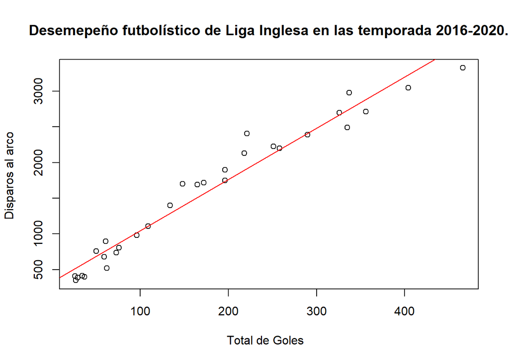

```r
regresion_lineal3<-lm(LigaInglaterra_equipo$gtshot_sum~ LigaInglaterra_equipo$gol_tem)
plot(LigaInglaterra_equipo$gol_tem, LigaInglaterra_equipo$gtshot_sum, main="Desemepeño futbolístico de Liga Inglesa en las temporada 2016-2020.",
        xlab="Total de Goles  ",
        ylab="Disparos al arco ",)
abline(regresion_lineal3, col='red')
```

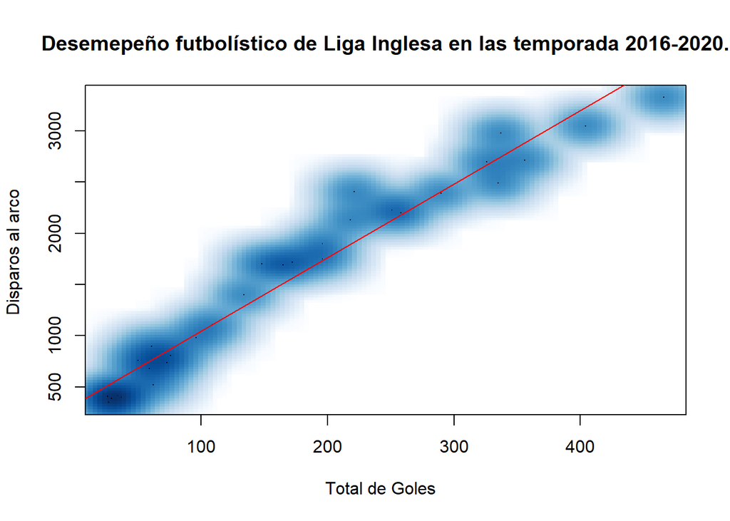

```r
smoothScatter(LigaInglaterra_equipo$gol_tem, LigaInglaterra_equipo$gtshot_sum, main="Desemepeño futbolístico de Liga Inglesa en las temporada 2016-2020.",
        xlab="Total de Goles  ",
        ylab="Disparos al arco ",)

abline(regresion_lineal3, col='red')
```

```r
summary(regresion_lineal3)
```

```
##
## Call:
## lm(formula = LigaInglaterra_equipo$gtshot_sum ~ LigaInglaterra_equipo$gol_tem)
##
## Residuals:
##     Min      1Q  Median      3Q     Max
## -349.23 -151.03   -8.55  127.13  492.98
##
## Coefficients:
##                               Estimate Std. Error t value Pr(>|t|)
## (Intercept)                   325.2413    59.9268   5.427 8.63e-06 ***
## LigaInglaterra_equipo$gol_tem   7.1845     0.2801  25.650  < 2e-16 ***
## ---
## Signif. codes:  0 '***' 0.001 '**' 0.01 '*' 0.05 '.' 0.1 ' ' 1
##
## Residual standard error: 191.6 on 28 degrees of freedom
## Multiple R-squared:  0.9592, Adjusted R-squared:  0.9577
## F-statistic: 657.9 on 1 and 28 DF,  p-value: < 2.2e-16
```

```r
coefficients(regresion_lineal3)
```

```
##                   (Intercept) LigaInglaterra_equipo$gol_tem
##                    325.241282                      7.184528
```

Entonces tenemos la siguiente formula:
$$\begin{equation}
f(x)= 325.241282 + 7.184528x
\end{equation}$$

```r
cor(LigaItalia_equipos$gol_tem, LigaItalia_equipos$gtshot_sum)
```

```
## [1] 0.9843356
```

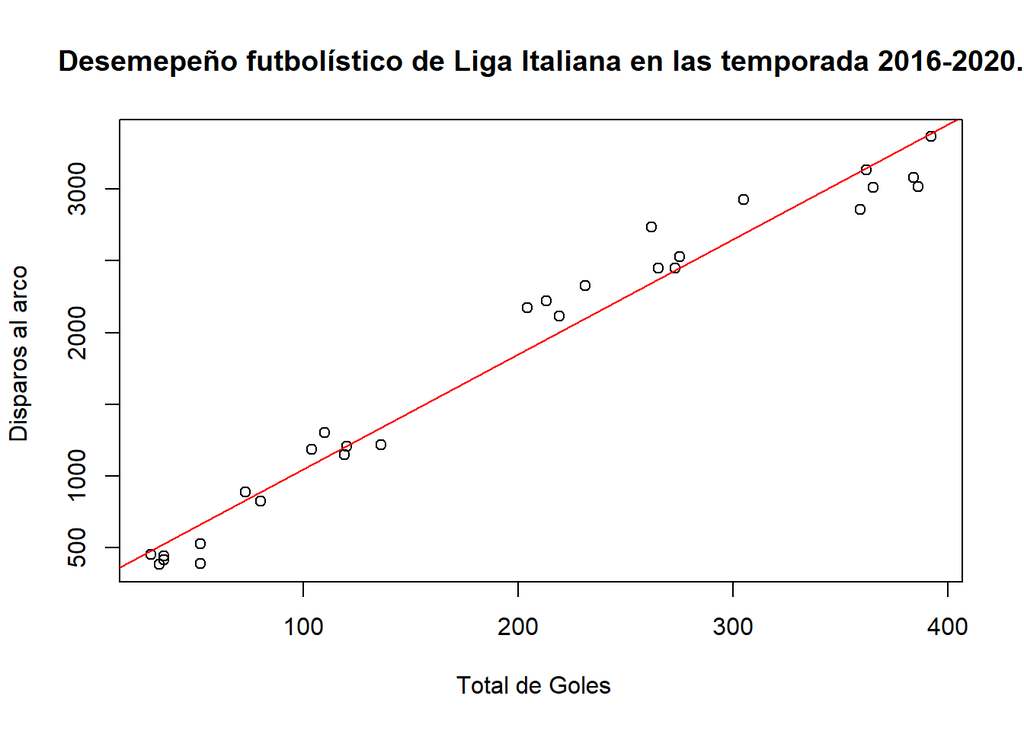

```r
regresion_lineal3<-lm(LigaItalia_equipos$gtshot_sum~ LigaItalia_equipos$gol_tem)
plot(LigaItalia_equipos$gol_tem, LigaItalia_equipos$gtshot_sum, main="Desemepeño futbolístico de Liga Italiana en las temporada 2016-2020.",
        xlab="Total de Goles  ",
        ylab="Disparos al arco ",)


abline(regresion_lineal3, col='red')
```

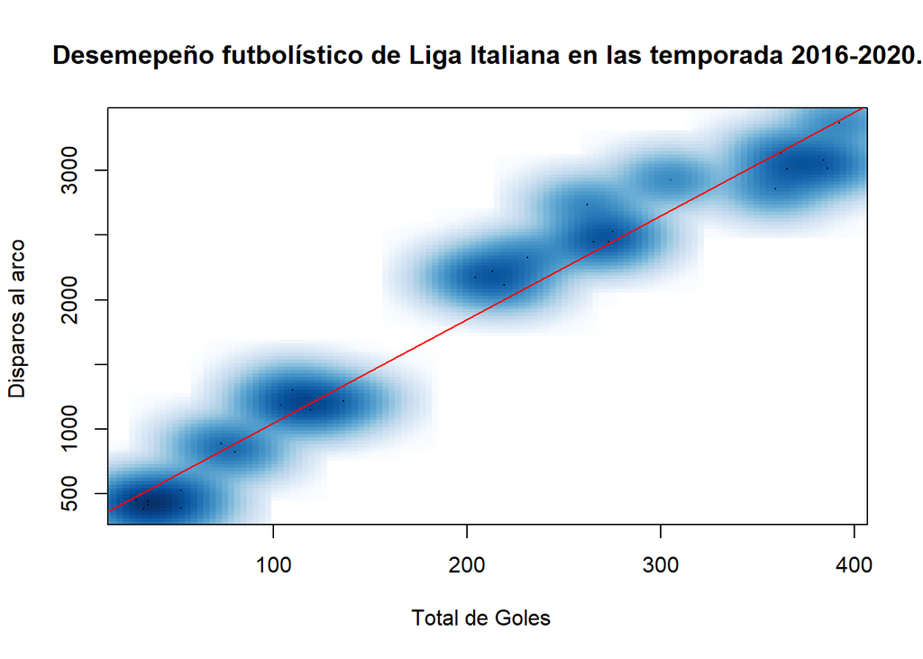

```r
smoothScatter(LigaItalia_equipos$gol_tem, LigaItalia_equipos$gtshot_sum,  main="Desemepeño futbolístico de Liga Italiana en las temporada 2016-2020.",
        xlab="Total de Goles  ",
        ylab="Disparos al arco ",)

abline(regresion_lineal3, col='red')
```

```r
summary(regresion_lineal3)
```

```
##
## Call:
## lm(formula = LigaItalia_equipos$gtshot_sum ~ LigaItalia_equipos$gol_tem)
##
## Residuals:
##     Min      1Q  Median      3Q     Max
## -321.80 -122.80  -20.17  107.62  390.00
##
## Coefficients:
##                            Estimate Std. Error t value Pr(>|t|)
## (Intercept)                247.1983    65.2706   3.787 0.000812 ***
## LigaItalia_equipos$gol_tem   8.0145     0.2815  28.469  < 2e-16 ***
## ---
## Signif. codes:  0 '***' 0.001 '**' 0.01 '*' 0.05 '.' 0.1 ' ' 1
##
## Residual standard error: 185.7 on 26 degrees of freedom
## Multiple R-squared:  0.9689, Adjusted R-squared:  0.9677
## F-statistic: 810.5 on 1 and 26 DF,  p-value: < 2.2e-16
```

```r
coefficients(regresion_lineal3)
```

```
##                (Intercept) LigaItalia_equipos$gol_tem
##                 247.198259                   8.014516
```

Entonces tenemos la siguiente formula:
$$\begin{equation}
f(x)= 247.198259 + 8.014516x
\end{equation}$$

| Ligas | Correlación |
| --- | --- |
| Alemana | 0.970891 |
| Españolo | 0.9561872 |
| Francesa | 0.9301711 |
| Inglesa | 0.9793769 |
| Italiana | 0.9843356 |

Se observa que la correlación de la selección Alemana, Española, Francesa, Inglesa e Italiana, con una correlación de 0.970891, 0.9561872, 0.9301711, 0.9793769 y 0.9843356, respectivamente. El valor se debe a la alta destreza de cada uno de los jugadores en realizar disparos al arco contrario y la probabilidad de gol es demasiada alta. Además, los jugadores que se encuentran involucrados son los delanteros y volantes extremos, tienen una probabilidad alta de gol. No obstante, los jugadores con el rol de medio campista, normalmente se enfocan en generar asistencias pero a la vez pueden realizar disparos al arco que pueden terminar convirtiéndose en goles. Por ello, las ligas con más disparos al arco son las que contienen a los jugadores con más experiencia ofensiva.

Liga Alemana Liga Espanola Liga Francesa Liga Inglesa Liga Italiana

```r
cor(ComportamientoLigaAlemanaa$gryellow_total, ComportamientoLigaAlemanaa$grfoul_total)
```

```
## [1] 0.9871623
```

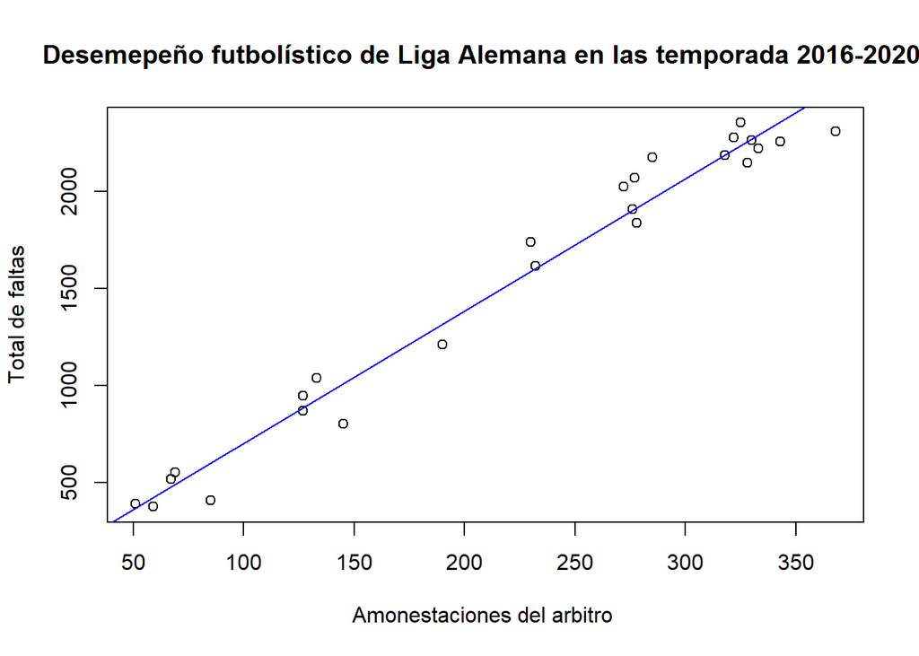

```r
regresion_lineal2<- lm(ComportamientoLigaAlemanaa$grfoul_total~ ComportamientoLigaAlemanaa$gryellow_total)
plot(ComportamientoLigaAlemanaa$gryellow_total, ComportamientoLigaAlemanaa$grfoul_total,  main="Desemepeño futbolístico de Liga Alemana en las temporada 2016-2020.",
        xlab="Amonestaciones del arbitro ",
        ylab="Total de faltas")
abline(regresion_lineal2, col='blue')
```

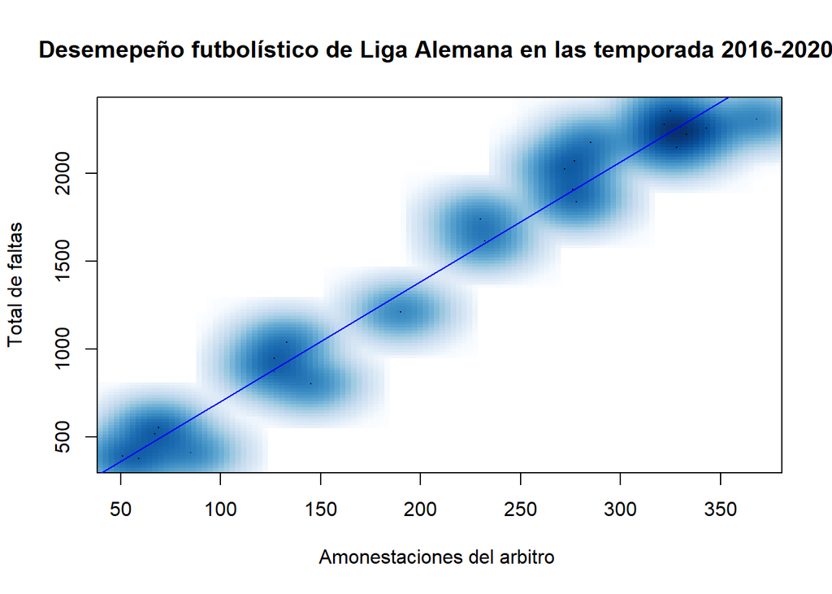

```r
smoothScatter(ComportamientoLigaAlemanaa$gryellow_total, ComportamientoLigaAlemanaa$grfoul_total,  main="Desemepeño futbolístico de Liga Alemana en las temporada 2016-2020.",
        xlab="Amonestaciones del arbitro ",
        ylab="Total de faltas")
abline(regresion_lineal2, col='blue')
```

```r
summary(regresion_lineal2)
```

```
##
## Call:
## lm(formula = ComportamientoLigaAlemanaa$grfoul_total ~ ComportamientoLigaAlemanaa$gryellow_total)
##
## Residuals:
##      Min       1Q   Median       3Q      Max
## -221.484  -78.490    6.132   62.824  211.833
##
## Coefficients:
##                                           Estimate Std. Error t value Pr(>|t|)
## (Intercept)                                22.0190    56.5221    0.39      0.7
## ComportamientoLigaAlemanaa$gryellow_total   6.8110     0.2298   29.64   <2e-16
##
## (Intercept)
## ComportamientoLigaAlemanaa$gryellow_total ***
## ---
## Signif. codes:  0 '***' 0.001 '**' 0.01 '*' 0.05 '.' 0.1 ' ' 1
##
## Residual standard error: 119.8 on 23 degrees of freedom
## Multiple R-squared:  0.9745, Adjusted R-squared:  0.9734
## F-statistic: 878.6 on 1 and 23 DF,  p-value: < 2.2e-16
```

```r
coefficients(regresion_lineal2)
```

```
##                               (Intercept)
##                                 22.019008
## ComportamientoLigaAlemanaa$gryellow_total
##                                  6.811046
```

Entonces tenemos la siguiente formula:
$$\begin{equation}
f(x)= 22.019008 + 6.811046x
\end{equation}$$

```r
cor(ComportamientoLigaEspanola$gryellow_total, ComportamientoLigaEspanola$grfoul_total)
```

```
## [1] 0.9872816
```

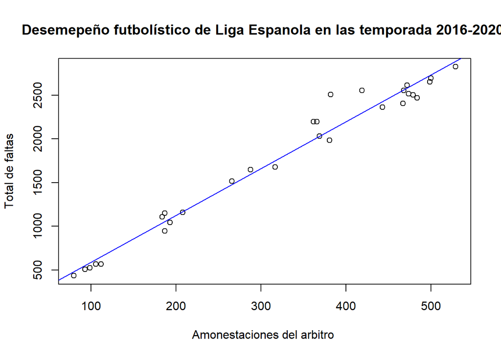

```r
regresion_lineal2<- lm(ComportamientoLigaEspanola$grfoul_total~ ComportamientoLigaEspanola$gryellow_total)
plot(ComportamientoLigaEspanola$gryellow_total, ComportamientoLigaEspanola$grfoul_total,  main="Desemepeño futbolístico de Liga Espanola en las temporada 2016-2020.",
        xlab="Amonestaciones del arbitro ",
        ylab="Total de faltas")
abline(regresion_lineal2, col='blue')
```

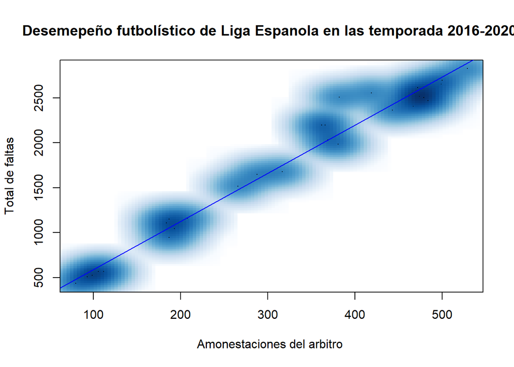

```r
smoothScatter(ComportamientoLigaEspanola$gryellow_total, ComportamientoLigaEspanola$grfoul_total,  main="Desemepeño futbolístico de Liga Espanola en las temporada 2016-2020.",
        xlab="Amonestaciones del arbitro ",
        ylab="Total de faltas")
abline(regresion_lineal2, col='blue')
```

```r
summary(regresion_lineal2)
```

```
##
## Call:
## lm(formula = ComportamientoLigaEspanola$grfoul_total ~ ComportamientoLigaEspanola$gryellow_total)
##
## Residuals:
##     Min      1Q  Median      3Q     Max
## -173.86  -74.22  -42.79   40.10  408.62
##
## Coefficients:
##                                           Estimate Std. Error t value Pr(>|t|)
## (Intercept)                                 50.771     59.131   0.859    0.398
## ComportamientoLigaEspanola$gryellow_total    5.358      0.166  32.268   <2e-16
##
## (Intercept)
## ComportamientoLigaEspanola$gryellow_total ***
## ---
## Signif. codes:  0 '***' 0.001 '**' 0.01 '*' 0.05 '.' 0.1 ' ' 1
##
## Residual standard error: 131 on 27 degrees of freedom
## Multiple R-squared:  0.9747, Adjusted R-squared:  0.9738
## F-statistic:  1041 on 1 and 27 DF,  p-value: < 2.2e-16
```

```r
coefficients(regresion_lineal2)
```

```
##                               (Intercept)
##                                 50.770564
## ComportamientoLigaEspanola$gryellow_total
##                                  5.357622
```

Entonces tenemos la siguiente formula:
$$\begin{equation}
f(x)= 50.770564 + 5.357622 x
\end{equation}$$

```r
cor(ComportamientoLigaFrancesa$gryellow_total, ComportamientoLigaFrancesa$grfoul_total)
```

```
## [1] 0.9765433
```

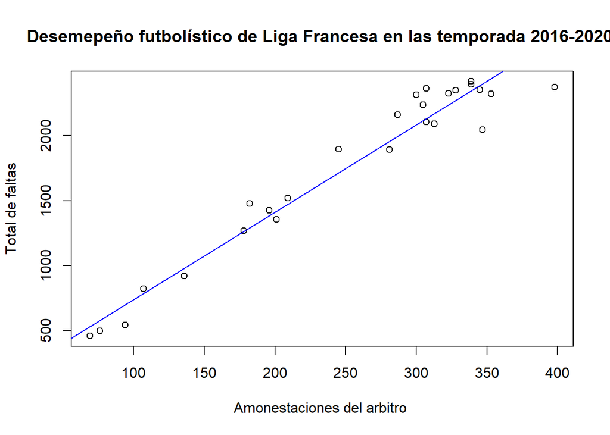

```r
regresion_lineal2<- lm(ComportamientoLigaFrancesa$grfoul_total~ ComportamientoLigaFrancesa$gryellow_total)
plot(ComportamientoLigaFrancesa$gryellow_total, ComportamientoLigaFrancesa$grfoul_total,  main="Desemepeño futbolístico de Liga Francesa en las temporada 2016-2020.",
        xlab="Amonestaciones del arbitro ",
        ylab="Total de faltas")
abline(regresion_lineal2, col='blue')
```

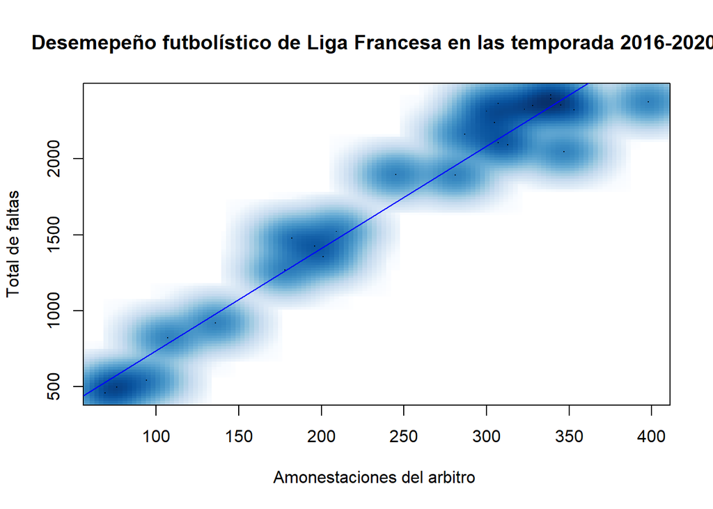

```r
smoothScatter(ComportamientoLigaFrancesa$gryellow_total, ComportamientoLigaFrancesa$grfoul_total,  main="Desemepeño futbolístico de Liga Francesa en las temporada 2016-2020.",
        xlab="Amonestaciones del arbitro ",
        ylab="Total de faltas")
abline(regresion_lineal2, col='blue')
```

```r
summary(regresion_lineal2)
```

```
##
## Call:
## lm(formula = ComportamientoLigaFrancesa$grfoul_total ~ ComportamientoLigaFrancesa$gryellow_total)
##
## Residuals:
##     Min      1Q  Median      3Q     Max
## -368.19  -74.55    5.97   81.92  234.47
##
## Coefficients:
##                                           Estimate Std. Error t value Pr(>|t|)
## (Intercept)                                63.6402    78.7058   0.809    0.426
## ComportamientoLigaFrancesa$gryellow_total   6.7325     0.2969  22.676   <2e-16
##
## (Intercept)
## ComportamientoLigaFrancesa$gryellow_total ***
## ---
## Signif. codes:  0 '***' 0.001 '**' 0.01 '*' 0.05 '.' 0.1 ' ' 1
##
## Residual standard error: 152.6 on 25 degrees of freedom
## Multiple R-squared:  0.9536, Adjusted R-squared:  0.9518
## F-statistic: 514.2 on 1 and 25 DF,  p-value: < 2.2e-16
```

```r
coefficients(regresion_lineal2)
```

```
##                               (Intercept)
##                                 63.640191
## ComportamientoLigaFrancesa$gryellow_total
##                                  6.732527
```

Entonces tenemos la siguiente formula:
$$\begin{equation}
f(x)= 63.640191 + 6.732527 x
\end{equation}$$

```r
cor(ComportamientoLigaInglesa$gryellow_total, ComportamientoLigaInglesa$grfoul_total)
```

```
## [1] 0.9788313
```

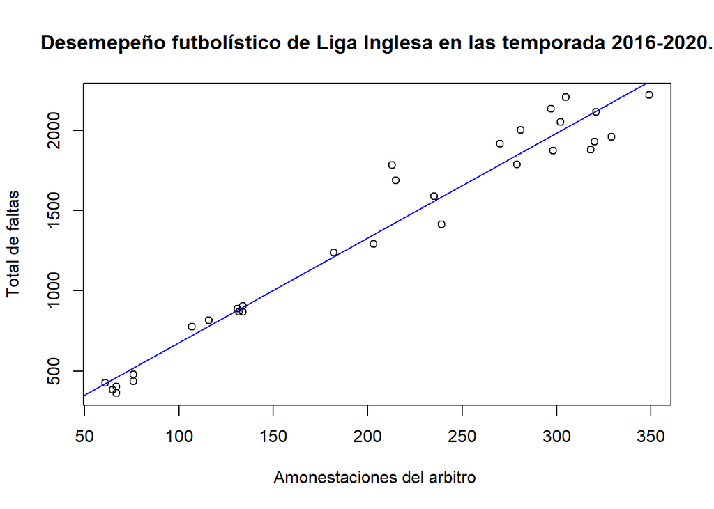

```r
regresion_lineal2<- lm(ComportamientoLigaInglesa$grfoul_total~ ComportamientoLigaInglesa$gryellow_total)
plot(ComportamientoLigaInglesa$gryellow_total, ComportamientoLigaInglesa$grfoul_total,  main="Desemepeño futbolístico de Liga Inglesa en las temporada 2016-2020.",
        xlab="Amonestaciones del arbitro ",
        ylab="Total de faltas")
abline(regresion_lineal2, col='blue')
```

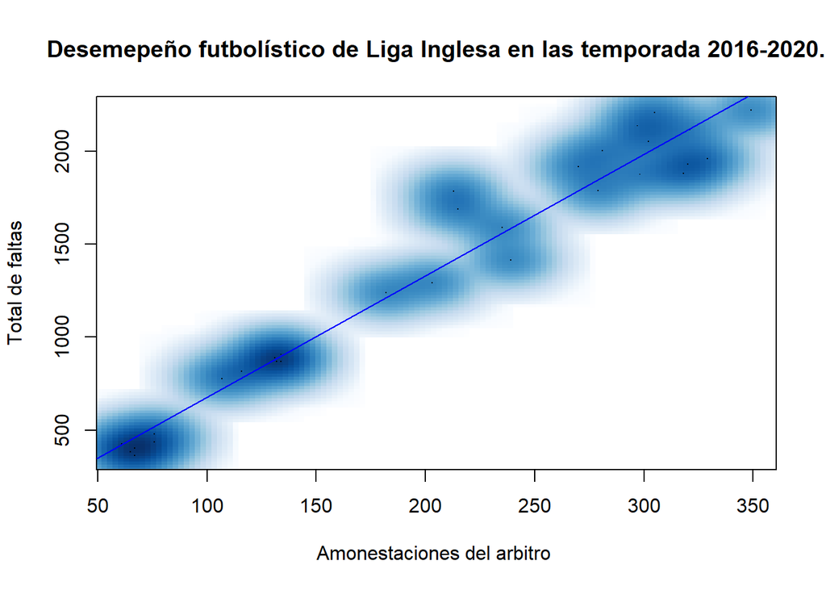

```r
smoothScatter(ComportamientoLigaInglesa$gryellow_total, ComportamientoLigaInglesa$grfoul_total,  main="Desemepeño futbolístico de Liga Inglesa en las temporada 2016-2020.",
        xlab="Amonestaciones del arbitro ",
        ylab="Total de faltas")
abline(regresion_lineal2, col='blue')
```

```r
summary(regresion_lineal2)
```

```
##
## Call:
## lm(formula = ComportamientoLigaInglesa$grfoul_total ~ ComportamientoLigaInglesa$gryellow_total)
##
## Residuals:
##     Min      1Q  Median      3Q     Max
## -222.29  -78.38  -11.44   50.15  367.76
##
## Coefficients:
##                                          Estimate Std. Error t value Pr(>|t|)
## (Intercept)                               23.5283    58.3010   0.404     0.69
## ComportamientoLigaInglesa$gryellow_total   6.5338     0.2582  25.307   <2e-16
##
## (Intercept)
## ComportamientoLigaInglesa$gryellow_total ***
## ---
## Signif. codes:  0 '***' 0.001 '**' 0.01 '*' 0.05 '.' 0.1 ' ' 1
##
## Residual standard error: 136.7 on 28 degrees of freedom
## Multiple R-squared:  0.9581, Adjusted R-squared:  0.9566
## F-statistic: 640.4 on 1 and 28 DF,  p-value: < 2.2e-16
```

```r
coefficients(regresion_lineal2)
```

```
##                              (Intercept)
##                                23.528300
## ComportamientoLigaInglesa$gryellow_total
##                                 6.533837
```

Entonces tenemos la siguiente formula:
$$\begin{equation}
f(x)= 23.528300 + 6.533837x
\end{equation}$$

```r
cor(ComportamientoLigaItaliana$gryellow_total, ComportamientoLigaItaliana$grfoul_total)
```

```
## [1] 0.9765301
```

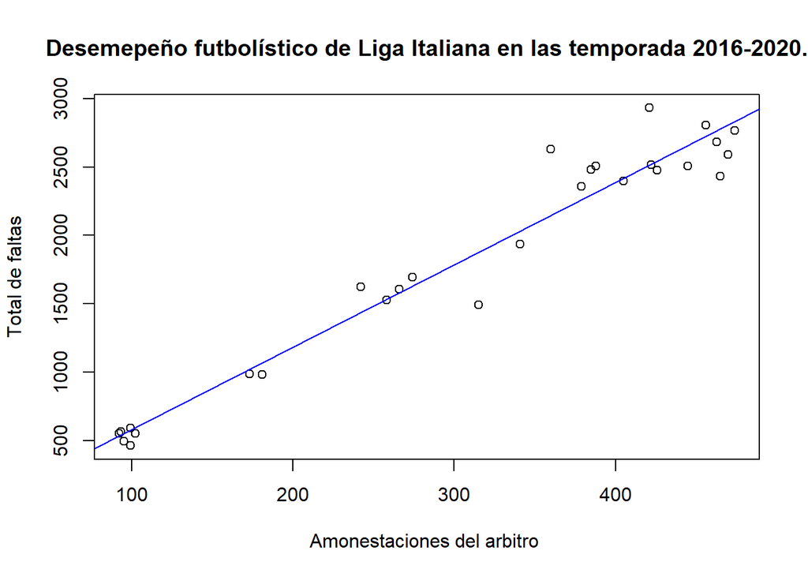

```r
regresion_lineal2<- lm(ComportamientoLigaItaliana$grfoul_total~ ComportamientoLigaItaliana$gryellow_total)
plot(ComportamientoLigaItaliana$gryellow_total, ComportamientoLigaItaliana$grfoul_total,  main="Desemepeño futbolístico de Liga Italiana en las temporada 2016-2020.",
        xlab="Amonestaciones del arbitro ",
        ylab="Total de faltas")
abline(regresion_lineal2, col='blue')
```

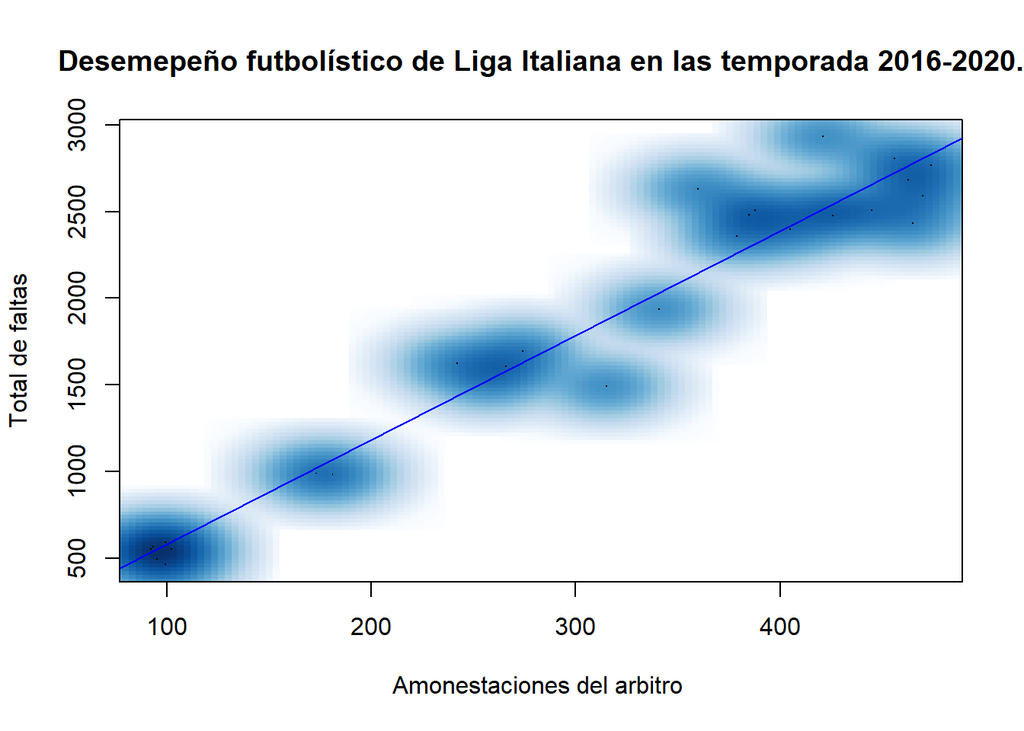

```r
smoothScatter(ComportamientoLigaItaliana$gryellow_total, ComportamientoLigaItaliana$grfoul_total,  main="Desemepeño futbolístico de Liga Italiana en las temporada 2016-2020.",
        xlab="Amonestaciones del arbitro ",
        ylab="Total de faltas")
abline(regresion_lineal2, col='blue')
```

```r
summary(regresion_lineal2)
```

```
##
## Call:
## lm(formula = ComportamientoLigaItaliana$grfoul_total ~ ComportamientoLigaItaliana$gryellow_total)
##
## Residuals:
##     Min      1Q  Median      3Q     Max
## -385.71  -85.14  -14.12   67.93  484.17
##
## Coefficients:
##                                           Estimate Std. Error t value Pr(>|t|)
## (Intercept)                               -21.1447    87.5526  -0.242    0.811
## ComportamientoLigaItaliana$gryellow_total   6.0249     0.2606  23.119   <2e-16
##
## (Intercept)
## ComportamientoLigaItaliana$gryellow_total ***
## ---
## Signif. codes:  0 '***' 0.001 '**' 0.01 '*' 0.05 '.' 0.1 ' ' 1
##
## Residual standard error: 188.9 on 26 degrees of freedom
## Multiple R-squared:  0.9536, Adjusted R-squared:  0.9518
## F-statistic: 534.5 on 1 and 26 DF,  p-value: < 2.2e-16
```

```r
coefficients(regresion_lineal2)
```

```
##                               (Intercept)
##                                -21.144657
## ComportamientoLigaItaliana$gryellow_total
##                                  6.024921
```

Entonces tenemos la siguiente formula:
$$\begin{equation}
f(x)= -21.144657 + 6.024921
\end{equation}$$

| Ligas | Correlación |
| --- | --- |
| Alemana | 0.9871623 |
| Españolo | 0.9872816 |
| Francesa | 0.9765433 |
| Inglesa | 0.9788313 |
| Italiana | 0.9765301 |

Se observa que las correlaciones entre todas las ligas cuentan con una ligera variedad, como lo observamos en la tabla de arriba. El valor obtenido es debido al comportamiento de cada jugador provocando jugadas de mucho contacto provocando la amonestación de tarjetas amarillas o rojas durante el desarrollo de cada partido. Esto demuestra el comportamiento y el profesionalismo de cada uno de los jugadores. Asimismo, mantiene una relación directamente proporcional, si la cantidad de faltas respecto a la cantidad de amonestaciones por parte del arbitro.

# 8. Analisis Probabilistico

### Modelos Probabilisticos

```r
estadistica_equipos%>%group_by(team) %>% summarise (total_goals= sum(goals),total_shots_OT = sum(shotsOnTarget), Proba_goles = round((total_goals/total_shots_OT), digits = 2), Proba_Atajadas = round(1-(total_goals/total_shots_OT), digits = 2)) %>% arrange(desc(total_goals)) ->IND_Efectividad
IND_Efectividad
```

| team | total_goals | total_shots_OT | Proba_goles | Proba_Atajadas |
| --- | --- | --- | --- | --- |
| Barcelona | 476 | 1261 | 0.38 | 0.62 |
| Bayern Munich | 468 | 1210 | 0.39 | 0.61 |
| Manchester City | 466 | 1225 | 0.38 | 0.62 |
| Paris Saint Germain | 457 | 1117 | 0.41 | 0.59 |
| Liverpool | 404 | 1140 | 0.35 | 0.65 |
| Real Madrid | 400 | 1174 | 0.34 | 0.66 |
| Napoli | 392 | 1214 | 0.32 | 0.68 |
| Juventus | 386 | 1086 | 0.36 | 0.64 |
| Atalanta | 384 | 1121 | 0.34 | 0.66 |
| Borussia Dortmund | 376 | 951 | 0.40 | 0.60 |

[output cut: 129 more lines]

En esta tabla, podemos observar la probabilidad que tiene los equipos al anotar gol y de atajarlo. Es decir, de todos los intentos al arco rival(total_shots_OT) cuántos de estos fueron goles(total_goals) para el casos de la variable Proba_goles y la para el caso Proba_Atajadas sería el complemente de la variable anterior.

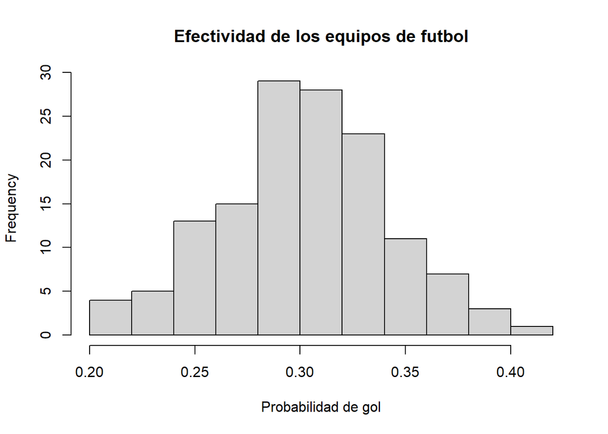

```r
hist(IND_Efectividad$Proba_goles, main = "Efectividad de los equipos de futbol", xlab = "Probabilidad de gol")
```

```r
shapiro.test(IND_Efectividad$Proba_goles)
```

```
##
##  Shapiro-Wilk normality test
##
## data:  IND_Efectividad$Proba_goles
## W = 0.99136, p-value = 0.5533
```

Debido a que el p-value nos sale mayor que 0.05 el cual es nuestro intervalo de confianza podemos asumir que la distribución para la efectividad de goles por equipo se asemeja a una distribución normal.

## Aplicación de axioma 3 para la probabilidad de agresividad

Para calcular la probabilidad de agresividad , primero calculamos la probabilidad de obtener tarjeta amarilla y roja, por simplicidad y obtener un analisis en el proyecto hemos tomado esto 2 eventos como mutuamente excluyentes para poder aplicar el axioma 3 y obtener la probabilidad de agresividad mediante la suma.

Tabla por equipos

| team | total_fouls | total_red_cards | total_yellow_cards | Prob_Agresividad_team |
| --- | --- | --- | --- | --- |
| Lecce | 463 | 5 | 99 | 0.22 |
| SPAL 2013 | 1491 | 10 | 315 | 0.22 |
| Las Palmas | 948 | 9 | 187 | 0.21 |
| Paderborn | 410 | 3 | 85 | 0.21 |
| Real Betis | 2470 | 26 | 484 | 0.21 |
| Valencia | 2404 | 27 | 467 | 0.21 |
| Alaves | 2824 | 25 | 529 | 0.20 |
| Barcelona | 1984 | 13 | 381 | 0.20 |
| Brescia | 494 | 6 | 95 | 0.20 |
| Celta Vigo | 2504 | 26 | 479 | 0.20 |

[output cut: 129 more lines]

Tabla por ligas

| league | total_fouls | total_red_cards | total_yellow_cards | Prob_Agresividad_liga |
| --- | --- | --- | --- | --- |
| La Liga | 51909 | 401 | 9414 | 0.19 |
| Serie A | 51156 | 440 | 8589 | 0.18 |
| Premier League | 40706 | 218 | 6122 | 0.16 |
| Bundesliga | 38488 | 230 | 5570 | 0.15 |
| Ligue 1 | 46429 | 454 | 6641 | 0.15 |

Debido a que la base de dato cuneta con las variables de probabilidades de concretar un gol y que una asistencia se convierta en gol para los jugadores de las 5 ligas, los agrupamos por las posiciones en las que juegan, Delanteros, medio campo, defensas.

# Probabilidad de gol

### Delanteros

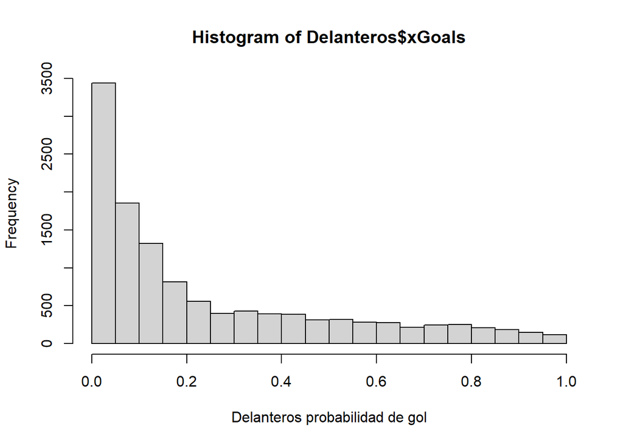

```r
hist(Delanteros$xGoals,xlab = "Delanteros probabilidad de gol")
```

```r
mean(Delanteros$xGoals)
```

```
## [1] 0.240255
```

```r
sqrt(var(Delanteros$xGoals))
```

```
## [1] 0.2626234
```

```r
sd(Delanteros$xGoals)
```

```
## [1] 0.2626234
```

Al realizar el experimento por teoría de una distribución exponencial, obtenemos que los valores de la media y desviación estándar son cercanos, casi similares lo que nos indica que es correcto afirmar que se asemeja a una distribución exponencial.

### Medio Campistas

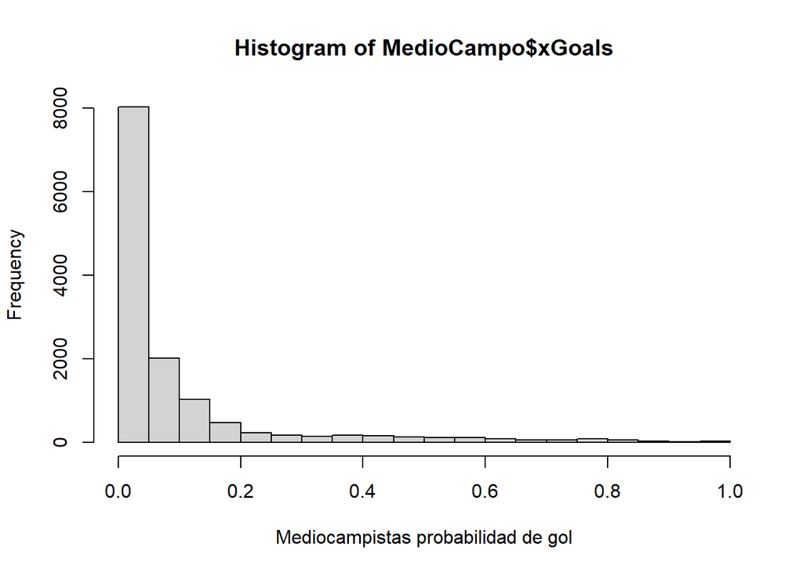

```r
hist(MedioCampo$xGoals,xlab = "Mediocampistas probabilidad de gol")
```

```r
mean(MedioCampo$xGoals)
```

```
## [1] 0.09286767
```

```r
sqrt(var(MedioCampo$xGoals))
```

```
## [1] 0.1675773
```

### Defensas

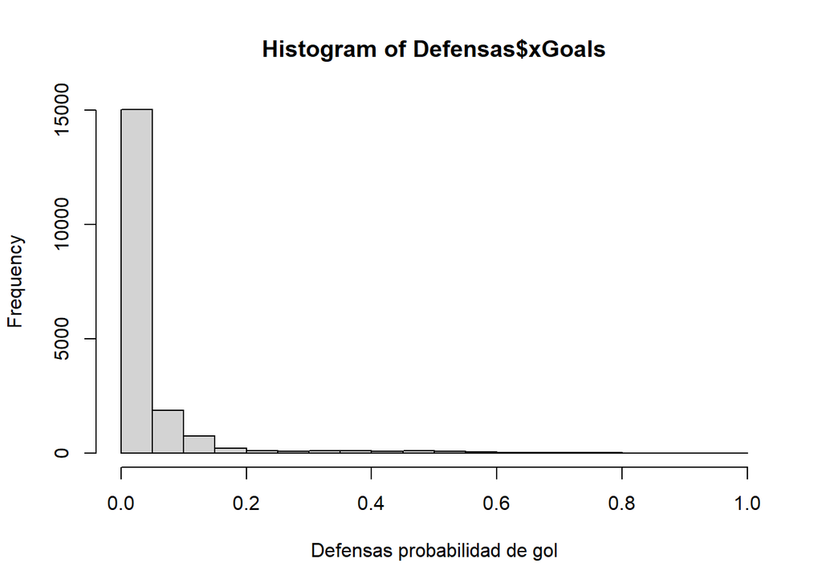

```r
hist(Defensas$xGoals,xlab = "Defensas probabilidad de gol")
```

```r
mean(Defensas$xGoals)
```

```
## [1] 0.04187072
```

```r
sqrt(var(Defensas$xGoals))
```

```
## [1] 0.1109093
```

Podemos apreciar en la gráfica que del valor de 0.2 a 1 la distribución puede considerarse uniforme, entonces procedemos a realizar los siguientes experimentos para corroborarlo:

```r
DefensasU <- filter(Defensas, xGoals >=0.2)
```

```r
mean(DefensasU$xGoals)
```

```
## [1] 0.4589381
```

```r
(min(DefensasU$xGoals)+max(DefensasU$xGoals))/2
```

```
## [1] 0.5874179
```

```r
((max(DefensasU$xGoals)-min(DefensasU$xGoals))^2)/12
```

```
## [1] 0.04999094
```

```r
var(DefensasU$xGoals)
```

```
## [1] 0.03303029
```

Después de realizar la prueba, se puede corroborar que los valores de la varianza y la media son distintos a los teoricos, por lo tanto no se puede considerar una distribucion uniforme.

# Probabilidad de un pase en convertirse en gol

### Delanteros

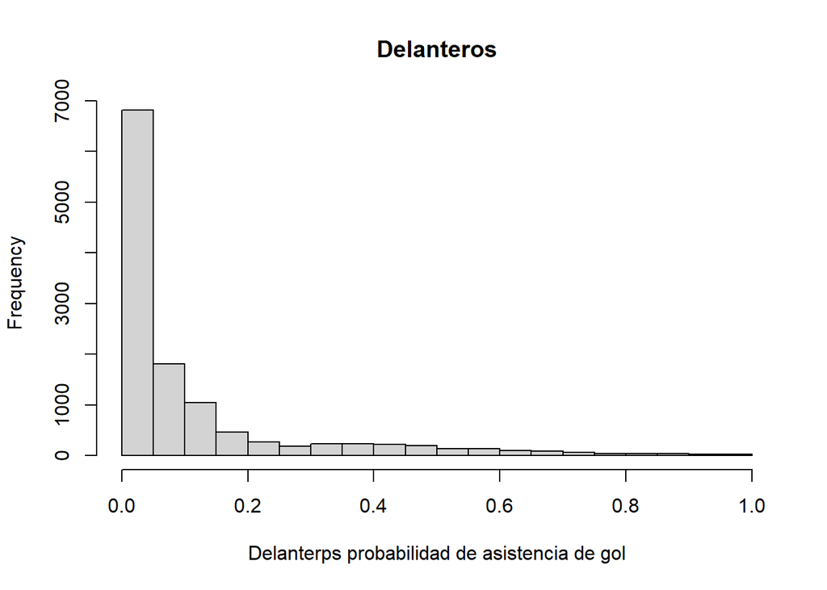

```r
hist(Delanteros$xGoalsBuildup,main = "Delanteros",xlab = "Delanterps probabilidad de asistencia de gol")
```

```r
mean(Delanteros$xGoalsBuildup)
```

```
## [1] 0.1079311
```

```r
sqrt(var(Delanteros$xGoalsBuildup))
```

```
## [1] 0.1758748
```